# Project Master

DURKA

29 05 2020

# Project I

## Introduction

Hello! Our team, ΔУРКА, which members are: Anastasia Gorokhova, Denis Kapitonov, Kirill Mukhin, and Fedor Shvets presenting you our project on topic ‘Frequency of Media Usage and Social Trust in Poland’. In this project, we will analyze ESS9-2018 data for Poland.

The main themes we will cover are how often do people consume information about politics and current affairs, frequency of Internet usage, trust level to people, opinion on purity of intent. These variables will compared among different socio-demographic variables as age, gender, marital status, higher level of education, employment status.

In this project each member contributed to its particular part (except the first step - research question which was contributed by everyone): * Anastasia Gorokhova - creating descriptive table; histogram, its code and description; * Denis Kapitonov - barplot, its code and description; decorative changes - legend, axis, and color customization; * Kirill Mukhin - creating a table of central tendency measures; stacked barplot, its code and description; * Fedor Shvets - boxplot, its code and description; satterplot, its code and description;

We upload necessary libraries and our original dataset of 1500 observations on 492 variables.

```r
library(ggplot2)
library(dplyr)
library(haven)
library(kableExtra)
library(car)
library(psych)
library(sjstats)
library(DescTools)
library(readr)
library(knitr)
library(labelled)
library(sjlabelled)
library(sjmisc)
library(ggeffects)
library(tidyverse)
library(magrittr)
library(cowplot)
library(gridExtra)
library(snakecase)
library(stargazer)
library(effects)
library(scales)
library(sjPlot)

ESS9 <- read_sav("C:/Users/fired/Desktop/UXA Maga/Projects/GitHub den1ceee/poland_survey_2020/ESS9PL.sav")
```

## Data Selection

```r
ESS_NEW = ESS9 %>% dplyr::select(nwspol, netusoft, netustm, ppltrst, pplfair, agea, gndr, marsts, eisced, emplrel, domicil)
str(ESS_NEW)
```

```
## tibble [1,500 x 11] (S3: tbl_df/tbl/data.frame)
##  $ nwspol  : dbl+lbl [1:1500]  20, 120,  80,  30,  30,  60,  15, 120,  30,  60,  30...
##    ..@ label      : chr "News about politics and current affairs, watching, reading or listening, in minutes"
##    ..@ format.spss: chr "F4.0"
##    ..@ labels     : Named num [1:3] 7777 8888 9999
##    .. ..- attr(*, "names")= chr [1:3] "Refusal" "Don't know" "No answer"
##  $ netusoft: dbl+lbl [1:1500] 5, 5, 5, 1, 5, 3, 5, 5, 1, 1, 4, 4, 5, 1, 5, 5, 2, 5,...
##    ..@ label        : chr "Internet use, how often"
##    ..@ format.spss  : chr "F1.0"
##    ..@ display_width: int 10
##    ..@ labels       : Named num [1:8] 1 2 3 4 5 7 8 9
##    .. ..- attr(*, "names")= chr [1:8] "Never" "Only occasionally" "A few times a week" "Most days" ...
##  $ netustm : dbl+lbl [1:1500]  60, 120, 180,  NA, 180,  NA,  90, 150,  NA,  NA,  60...
##    ..@ label        : chr "Internet use, how much time on typical day, in minutes"
##    ..@ format.spss  : chr "F4.0"
##    ..@ display_width: int 9
##    ..@ labels       : Named num [1:4] 6666 7777 8888 9999
##    .. ..- attr(*, "names")= chr [1:4] "Not applicable" "Refusal" "Don't know" "No answer"
##  $ ppltrst : dbl+lbl [1:1500]  2,  3,  2,  2,  7,  1,  7,  3,  0,  5,  5,  7,  3,  ...
##    ..@ label        : chr "Most people can be trusted or you can't be too careful"
##    ..@ format.spss  : chr "F2.0"
##    ..@ display_width: int 9
##    ..@ labels       : Named num [1:14] 0 1 2 3 4 5 6 7 8 9 ...
##    .. ..- attr(*, "names")= chr [1:14] "You can't be too careful" "1" "2" "3" ...
##  $ pplfair : dbl+lbl [1:1500]  6,  4,  7,  3,  7,  4,  8,  5,  2,  5,  5,  7,  7, 1...
##    ..@ label        : chr "Most people try to take advantage of you, or try to be fair"
##    ..@ format.spss  : chr "F2.0"
##    ..@ display_width: int 9
##    ..@ labels       : Named num [1:14] 0 1 2 3 4 5 6 7 8 9 ...
##    .. ..- attr(*, "names")= chr [1:14] "Most people try to take advantage of me" "1" "2" "3" ...
##  $ agea    : dbl+lbl [1:1500] 37, 23, 22, 83, 36, 32, 29, 72, 45, 63, 33, 51, 27, 7...
##    ..@ label        : chr "Age of respondent, calculated"
##    ..@ format.spss  : chr "F4.0"
##    ..@ display_width: int 6
##    ..@ labels       : Named num 999
##    .. ..- attr(*, "names")= chr "Not available"
##  $ gndr    : dbl+lbl [1:1500] 2, 1, 2, 2, 1, 1, 2, 1, 1, 1, 2, 2, 2, 2, 2, 2, 1, 2,...
##    ..@ label        : chr "Gender"
##    ..@ format.spss  : chr "F1.0"
##    ..@ display_width: int 6
```

[output cut: 10 more lines]

```
##    ..@ display_width: int 10
##    ..@ labels       : Named num [1:12] 0 1 2 3 4 5 6 7 55 77 ...
##    .. ..- attr(*, "names")= chr [1:12] "Not possible to harmonise into ES-ISCED" "ES-ISCED I , less than lower secondary" "ES-ISCED II, lower secondary" "ES-ISCED IIIb, lower tier upper secondary" ...
##  $ emplrel : dbl+lbl [1:1500]  1,  1,  1,  1,  1,  1,  1,  1,  1,  1,  1,  1,  1,  ...
##    ..@ label        : chr "Employment relation"
##    ..@ format.spss  : chr "F1.0"
##    ..@ display_width: int 9
##    ..@ labels       : Named num [1:7] 1 2 3 6 7 8 9
##    .. ..- attr(*, "names")= chr [1:7] "Employee" "Self-employed" "Working for own family business" "Not applicable" ...
##  $ domicil : dbl+lbl [1:1500] 4, 4, 1, 1, 1, 4, 3, 1, 4, 3, 3, 2, 1, 4, 3, 4, 4, 3,...
##    ..@ label        : chr "Domicile, respondent's description"
##    ..@ format.spss  : chr "F1.0"
##    ..@ display_width: int 9
##    ..@ labels       : Named num [1:8] 1 2 3 4 5 7 8 9
##    .. ..- attr(*, "names")= chr [1:8] "A big city" "Suburbs or outskirts of big city" "Town or small city" "Country village" ...
```

```r
str(ESS_NEW$emplrel)
```

```
##  dbl+lbl [1:1500]  1,  1,  1,  1,  1,  1,  1,  1,  1,  1,  1,  1,  1,  2,  ...
##  @ label        : chr "Employment relation"
##  @ format.spss  : chr "F1.0"
##  @ display_width: int 9
##  @ labels       : Named num [1:7] 1 2 3 6 7 8 9
##   ..- attr(*, "names")= chr [1:7] "Employee" "Self-employed" "Working for own family business" "Not applicable" ...
```

## Data Description

In order to describe variables we have, we create three vectors with original names, description, and variable types.

```r
Variable_Name = c('nwspol', 'netusoft', 'netustm', 'ppltrst', 'domicil', 'agea', 'gndr', 'marsts', 'eisced', 'emplrel')

Description = c('Frequency of consuming (watching, reading, or listening) information about politics and current affairs', 'Frequency of Internet usage', 'Frequency of Internet usage on usual day in minutes', 'Level of trust', 'Domicile', 'Calculated age of a respondent', 'Sex of a respondent', 'Marital status of a respondent', 'Highest level of education of a respondent on European survey version of ISCED scale', 'Employment relation of a respondent')

Variable_Type = c('Ratio', 'Ordinal', 'Ratio', 'Nominal', 'Ordinal', 'Ratio', 'Nominal', 'Nominal', 'Ordinal', 'Nominal')
```

Further, we combine these vectors in a data frame to provide more convenient way of representation.

```r
data_description <- data.frame(Variable_Name, Description, Variable_Type, stringsAsFactors = FALSE)

kable(data_description) %>%
  kable_styling(bootstrap_options = c('bordered'), full_width = FALSE)
```

| Variable_Name | Description | Variable_Type |
| --- | --- | --- |
| nwspol | Frequency of consuming (watching, reading, or listening) information about politics and current affairs | Ratio |
| netusoft | Frequency of Internet usage | Ordinal |
| netustm | Frequency of Internet usage on usual day in minutes | Ratio |
| ppltrst | Level of trust | Nominal |
| domicil | Domicile | Ordinal |
| agea | Calculated age of a respondent | Ratio |
| gndr | Sex of a respondent | Nominal |
| marsts | Marital status of a respondent | Nominal |
| eisced | Highest level of education of a respondent on European survey version of ISCED scale | Ordinal |
| emplrel | Employment relation of a respondent | Nominal |

## Central Tendency Measures Table

To create descriptive table for central tendency measures we firstly create a Mode function.

```r
Mode <- function(x) {
  ux <- unique(x)
  ux[which.max(tabulate(match(x, ux)))]
}
```

There we explore variables of which class do we have.

```r
class(ESS_NEW$nwspol)
```

```
## [1] "haven_labelled" "vctrs_vctr"     "double"
```

```r
class(ESS_NEW$netusoft)
```

```
## [1] "haven_labelled" "vctrs_vctr"     "double"
```

```r
class(ESS_NEW$netustm)
```

```
## [1] "haven_labelled" "vctrs_vctr"     "double"
```

```r
class(ESS_NEW$ppltrst)
```

```
## [1] "haven_labelled" "vctrs_vctr"     "double"
```

```r
class(ESS_NEW$pplfair)
```

```
## [1] "haven_labelled" "vctrs_vctr"     "double"
```

```r
class(ESS_NEW$agea)
```

```
## [1] "haven_labelled" "vctrs_vctr"     "double"
```

As we can see, all of these variables are of haven_labelled type, so we should treat them as numeric one. To do this, we firstly re-class them to numeric type.

```r
ESS_NEW$nwspol = as.numeric(ESS_NEW$nwspol)
ESS_NEW$netusoft = as.numeric(ESS_NEW$netusoft)
ESS_NEW$netustm = as.numeric(ESS_NEW$netustm)
ESS_NEW$ppltrst = as.numeric(ESS_NEW$ppltrst)
ESS_NEW$pplfair = as.numeric(ESS_NEW$pplfair)
ESS_NEW$agea = as.numeric(ESS_NEW$agea)
```

```r
m_nwspol <- c(round(mean(na.omit(ESS_NEW$nwspol)), digits = 2), round(Mode(na.omit(ESS_NEW$nwspol)), digits = 0),round(median(na.omit(ESS_NEW$nwspol)), digits = 0))
m_netusoft <- c(round(mean(na.omit(ESS_NEW$netusoft)), digits = 2), round(Mode(na.omit(ESS_NEW$netusoft))), round(median(na.omit(ESS_NEW$netusoft))))
m_netustm <- c(round(mean(na.omit(ESS_NEW$netustm)), digits = 2), round(Mode(na.omit(ESS_NEW$netustm))), round(median(na.omit(ESS_NEW$netustm))))
m_ppltrst <- c(round(mean(na.omit(ESS_NEW$ppltrst)), digits = 2), round(Mode(na.omit(ESS_NEW$ppltrst))), round(median(na.omit(ESS_NEW$ppltrst))))
m_agea <- c(round(mean(na.omit(ESS_NEW$agea)), digits = 2), round(Mode(na.omit(ESS_NEW$agea))), round(median(na.omit(ESS_NEW$agea))))
```

```r
descriptives_table =  data.frame(m_nwspol, m_netusoft, m_netustm, m_ppltrst, m_agea, stringsAsFactors = FALSE)
rownames(descriptives_table) <- c("Mean", "Mode", "Median")

kable(descriptives_table) %>%
  kable_styling(bootstrap_options = c('bordered'), full_width = FALSE)
```

|  | m_nwspol | m_netusoft | m_netustm | m_ppltrst | m_agea |
| --- | --- | --- | --- | --- | --- |
| Mean | 88.27 | 3.56 | 182.27 | 4.04 | 47.62 |
| Mode | 60.00 | 5.00 | 120.00 | 5.00 | 62.00 |
| Median | 60.00 | 5.00 | 120.00 | 4.00 | 47.00 |

## Histogram

There we start to analyze data we have using ggplot2 package.

1. How long do people in Poland use the Internet during the day? And how do these indicators differ between the genders?

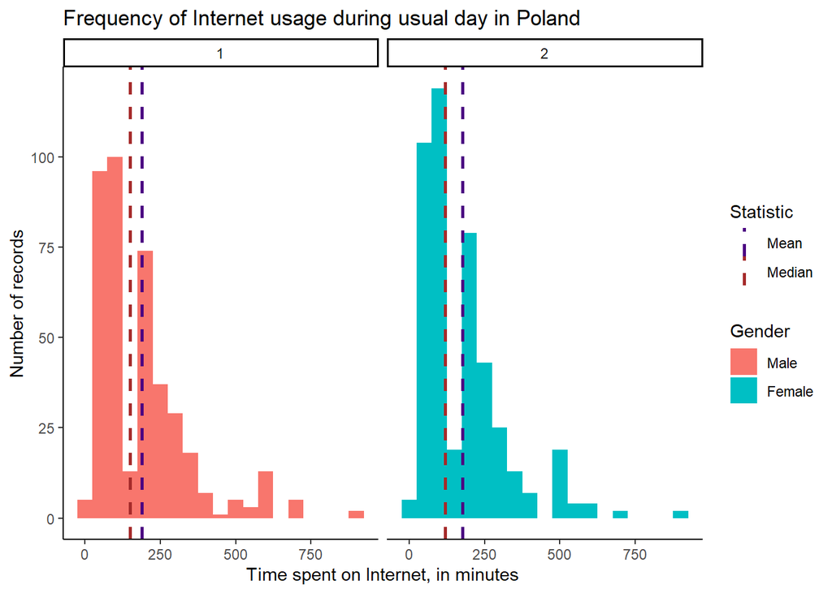

```r
z = ESS_NEW %>% group_by(gndr) %>% dplyr::summarise(avg = mean(na.omit(netustm)), med = median(na.omit(netustm)))

ggplot(filter(ESS_NEW, !is.na(netustm)), aes(netustm, fill = as.factor(gndr))) +
  geom_histogram(binwidth = 50) +
  facet_wrap(. ~ gndr) +
  geom_vline(data = z, aes(xintercept = avg, color = 'Mean'), linetype = 'dashed', size = 1) +
  geom_vline(data = z, aes(xintercept = med, color = 'Median'), linetype = 'dashed', size = 1) +
  ggtitle('Frequency of Internet usage during usual day in Poland') +
  xlab('Time spent on Internet, in minutes') +
  ylab('Number of records') +
  scale_fill_discrete(name = 'Gender', labels = c('Male', 'Female')) +
  scale_color_manual(name = 'Statistic', values = c(Mean = '#4B0082', Median = '#A52A2A')) +
  theme_classic()
```

THe distributions in both cases are non normal, right-skewed. There we can see that the biggest part of respondents tend to use Internet less than 3 hours. There we can also unexpected downgrade in around 130 minutes. Starting with approximately 250 minutes we can notice decrease in amount of female internet users, but on 500 minutes they start to dominate.

## Barplot

2. What marital status is most common in Poland?

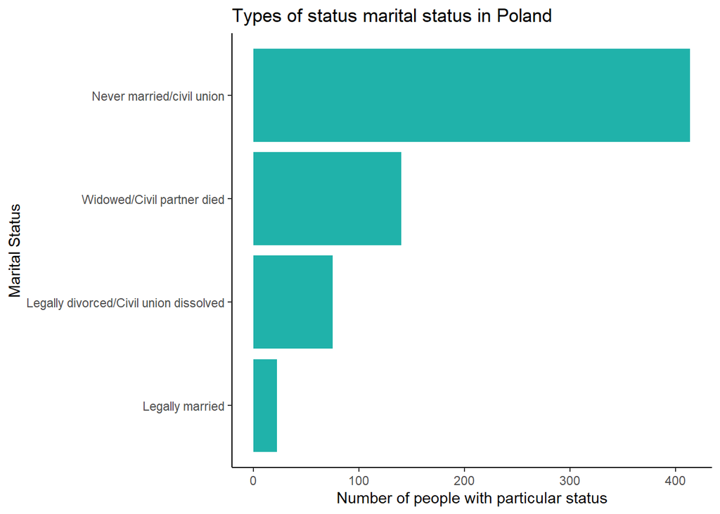

```r
ggplot(filter(ESS_NEW, !is.na(marsts)), aes(as.factor(marsts))) +
  geom_bar(fill = '#20B2AA') +
  ggtitle('Types of status marital status in Poland') +
  xlab("Marital status)") +
  ylab('Number of people with particular status') +
  scale_x_discrete(name = 'Marital Status', labels = c('Legally married', 'Legally divorced/Civil union dissolved', 'Widowed/Civil partner died', 'Never married/civil union')) +
  theme_classic()+
  coord_flip()
```

So, we can see that people in Poland do not aim to have legal marriage. Most of them don’t have such experience. Moreover, it looks like there are more divorced couples that those who are married. We can assume that institution of marriage in Poland is going through crisis.

## Scatterplot

3. Is there any association between age and the time spent on consuming information in different form about politics and current affairs?

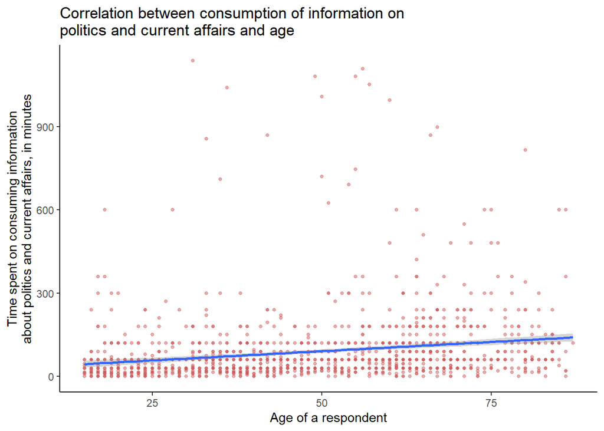

```r
ggplot(filter(ESS_NEW, !is.na(nwspol)), aes(x = as.numeric(agea), y = as.numeric(nwspol))) +
  geom_point(size = 1, alpha = 0.5, color = '#CD5C5C') +
  geom_smooth(method = 'lm') +
  ggtitle('Correlation between consumption of information on\npolitics and current affairs and age') +
  xlab('Age of a respondent') +
  xlim(15, NA)+
  ylab('Time spent on consuming information\nabout politics and current affairs, in minutes') +
  theme_classic()
```

## Boxplot

4. Is there any correlation between the frequency of Internet consumption and employment relations by marital status?

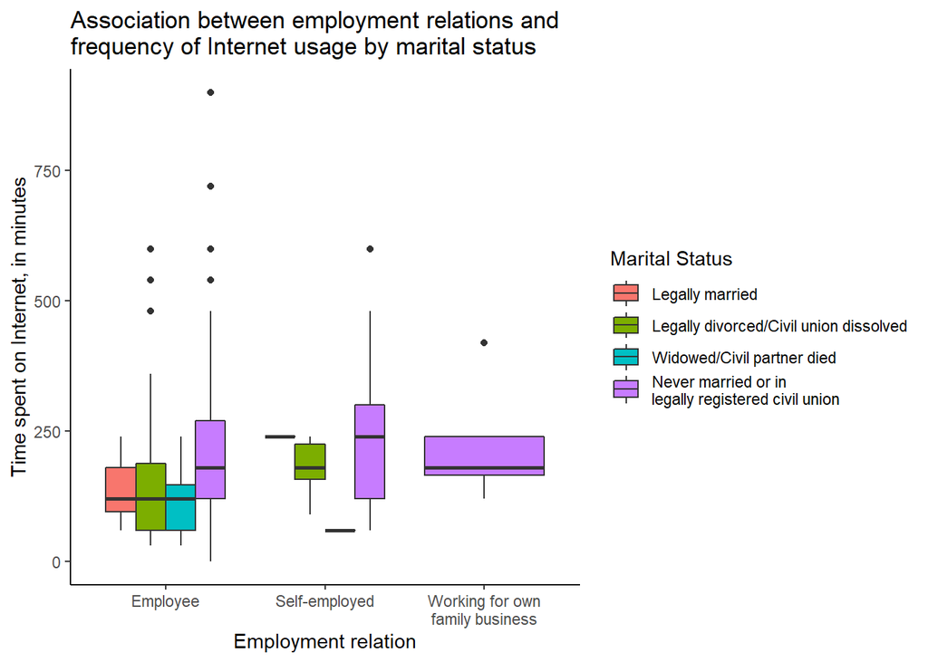

```r
ggplot(filter(ESS_NEW, !is.na(emplrel), !is.na(marsts), !is.na(netustm))) +
  geom_boxplot(aes(x = as.factor(emplrel), y = as.numeric(netustm), fill = as.factor(marsts)), position = 'dodge') +
  ggtitle('Association between employment relations and\nfrequency of Internet usage by marital status') +
  xlab('Employment relation') +
  ylab('Time spent on Internet, in minutes') +
  scale_fill_discrete(name = 'Marital Status', labels = c('Legally married', 'Legally divorced/Civil union dissolved', 'Widowed/Civil partner died', 'Never married or in\nlegally registered civil union')) +
  scale_x_discrete(labels = c('Employee', 'Self-employed', 'Working for own\nfamily business')) +
  theme_classic()
```

## Stacked Barplot

Is there any relation between place of living and level of trust?

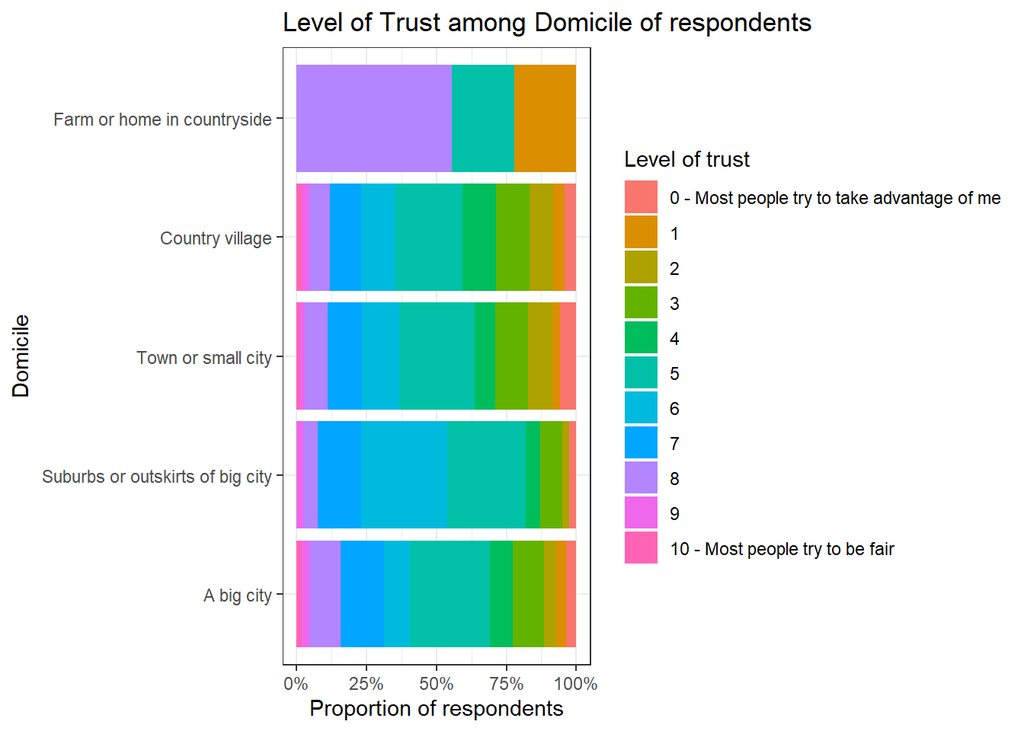

```r
ggplot(filter(ESS_NEW, !is.na( domicil), !is.na(pplfair)), aes(x = as.factor(domicil), fill = as.factor(pplfair))) +
  ggtitle('Level of Trust among Domicile of respondents') +
  xlab('current activity') +
  ylab('Proportion of respondents') +
  scale_y_continuous(labels = scales::percent_format()) +
  scale_fill_discrete(name = "Level of trust", labels = c("0 - Most people try to take advantage of me", "1", "2", "3", "4", "5", "6", "7", "8", "9", "10 - Most people try to be fair")) +
  scale_x_discrete( name = "Domicile", labels = c("A big city", " Suburbs or outskirts of big city", "Town or small city", " Country village", "Farm or home in countryside")) +
  geom_bar(position = "fill") +
  coord_flip() +
  theme_bw()
```

# Project II

## Introduction

Hello! This is our team ΔУРКА again, which members are: Anastasia Gorokhova, Denis Kapitonov, Kirill Mukhin, and Fedor Shvets presenting you our project on topic ‘Media and Social Trust’. In this project, we will conduct Chi-squared test, T-test and ANOVA F-test.

In this project each member contributed to its particular part: * Anastasia Gorokhova – conducting T-test with preparing a data, checking the normality in two ways, formulating hypothesis, conducting all formal tests and making conclusions * Denis Kapitonov - selecting the necessary variables, describing them, constructing a table with variables, visual design of the project * Kirill Mukhin – conducting ANOVA F-test with variable preparation, checking the distribution, conducting all formal tests, formulating hypothesis and making conclusions * Fedor Shvets – conducting Chi-squared test with constructing contingency table, formulating hypothesis, conducting a test, checking the results with the visualization of residuals and making conclusions

## Data Selection

For each test we select variables from the dataset. However, in the block “Media and social trust” there are no exact categorical or nominal vatiable, and because of this we decided to interpret some ordinal variables as categotical.

```r
ESS_NEW1 = ESS9 %>% dplyr::select(domicil, nwspol, netustm, pplfair, gndr, marsts, netusoft)
str(ESS_NEW1)
```

```
## tibble [1,500 x 7] (S3: tbl_df/tbl/data.frame)
##  $ domicil : dbl+lbl [1:1500] 4, 4, 1, 1, 1, 4, 3, 1, 4, 3, 3, 2, 1, 4, 3, 4, 4, 3,...
##    ..@ label        : chr "Domicile, respondent's description"
##    ..@ format.spss  : chr "F1.0"
##    ..@ display_width: int 9
##    ..@ labels       : Named num [1:8] 1 2 3 4 5 7 8 9
##    .. ..- attr(*, "names")= chr [1:8] "A big city" "Suburbs or outskirts of big city" "Town or small city" "Country village" ...
##  $ nwspol  : dbl+lbl [1:1500]  20, 120,  80,  30,  30,  60,  15, 120,  30,  60,  30...
##    ..@ label      : chr "News about politics and current affairs, watching, reading or listening, in minutes"
##    ..@ format.spss: chr "F4.0"
##    ..@ labels     : Named num [1:3] 7777 8888 9999
##    .. ..- attr(*, "names")= chr [1:3] "Refusal" "Don't know" "No answer"
##  $ netustm : dbl+lbl [1:1500]  60, 120, 180,  NA, 180,  NA,  90, 150,  NA,  NA,  60...
##    ..@ label        : chr "Internet use, how much time on typical day, in minutes"
##    ..@ format.spss  : chr "F4.0"
##    ..@ display_width: int 9
##    ..@ labels       : Named num [1:4] 6666 7777 8888 9999
##    .. ..- attr(*, "names")= chr [1:4] "Not applicable" "Refusal" "Don't know" "No answer"
##  $ pplfair : dbl+lbl [1:1500]  6,  4,  7,  3,  7,  4,  8,  5,  2,  5,  5,  7,  7, 1...
##    ..@ label        : chr "Most people try to take advantage of you, or try to be fair"
##    ..@ format.spss  : chr "F2.0"
##    ..@ display_width: int 9
##    ..@ labels       : Named num [1:14] 0 1 2 3 4 5 6 7 8 9 ...
##    .. ..- attr(*, "names")= chr [1:14] "Most people try to take advantage of me" "1" "2" "3" ...
##  $ gndr    : dbl+lbl [1:1500] 2, 1, 2, 2, 1, 1, 2, 1, 1, 1, 2, 2, 2, 2, 2, 2, 1, 2,...
##    ..@ label        : chr "Gender"
##    ..@ format.spss  : chr "F1.0"
##    ..@ display_width: int 6
##    ..@ labels       : Named num [1:3] 1 2 9
##    .. ..- attr(*, "names")= chr [1:3] "Male" "Female" "No answer"
##  $ marsts  : dbl+lbl [1:1500] NA,  6,  6, NA, NA,  6,  6,  5, NA,  6,  6,  6, NA, N...
##    ..@ label      : chr "Legal marital status"
##    ..@ format.spss: chr "F2.0"
##    ..@ labels     : Named num [1:10] 1 2 3 4 5 6 66 77 88 99
##    .. ..- attr(*, "names")= chr [1:10] "Legally married" "In a legally registered civil union" "Legally separated" "Legally divorced/Civil union dissolved" ...
##  $ netusoft: dbl+lbl [1:1500] 5, 5, 5, 1, 5, 3, 5, 5, 1, 1, 4, 4, 5, 1, 5, 5, 2, 5,...
##    ..@ label        : chr "Internet use, how often"
##    ..@ format.spss  : chr "F1.0"
##    ..@ display_width: int 10
##    ..@ labels       : Named num [1:8] 1 2 3 4 5 7 8 9
##    .. ..- attr(*, "names")= chr [1:8] "Never" "Only occasionally" "A few times a week" "Most days" ...
```

## Data Description

In order to describe variables we have, we create four vectors with original names, description, variable types and test type

```r
Variable_Name = c('domicil', 'nwspol', 'netustm', 'gndr', 'marsts', 'netusoft')

Description = c('Respondent description of his/her domicile', 'Frequency of consuming (watching, reading, or listening) information about politics and current affairs', 'Frequency of Internet usage on usual day in minutes', 'Sex of a respondent', 'Marital status of a respondent', 'Frequency of Internet usage')

Variable_Type = c('Nominal', 'Ratio', 'Ratio', 'Nominal', 'Nominal', 'Ordinal')

Test_Type <- c("Chi-squared test", "T-test for independet variables", "ANOVA", "T-test for independet variables", "ANOVA", "Chi-squared test")
```

Further, we combine these vectors in a data frame to provide more convenient way of representation.

```r
data_description <- data.frame(Variable_Name, Description, Variable_Type, Test_Type, stringsAsFactors = FALSE)

kable(data_description) %>%
  kable_styling(bootstrap_options = c('bordered'), full_width = FALSE)
```

| Variable_Name | Description | Variable_Type | Test_Type |
| --- | --- | --- | --- |
| domicil | Respondent description of his/her domicile | Nominal | Chi-squared test |
| nwspol | Frequency of consuming (watching, reading, or listening) information about politics and current affairs | Ratio | T-test for independet variables |
| netustm | Frequency of Internet usage on usual day in minutes | Ratio | ANOVA |
| gndr | Sex of a respondent | Nominal | T-test for independet variables |
| marsts | Marital status of a respondent | Nominal | ANOVA |
| netusoft | Frequency of Internet usage | Ordinal | Chi-squared test |

## Chi-Squared Test

Conducting Chi-squared test

Step 1. Constructing contengency table.

For Chi-squared test we chose two variables. One categorical variable – “Respondent description of his/her domicile” and one ordinal variable, which is we also interpret as categorical – “Frequency of use of the Internet or other devices for work or personal aims”. Some categories of our categorical variable have less than 5 observations in the contingency table cells, so we merge them with a bigger one (“Suburbs or outskirts of big city” with “A big city” and “Farm or home in countryside” with “Country village”).

```r
ESS_NEW1$domicil1[ ESS_NEW1$domicil == 1 |
                  ESS_NEW1$domicil == 2 ] <- 1
ESS_NEW1$domicil1[ ESS_NEW1$domicil == 3 ] <- 2
ESS_NEW1$domicil1[ ESS_NEW1$domicil == 4 |
                  ESS_NEW1$domicil == 5 ] <- 3

media_chi <- ESS_NEW1 %>% dplyr::select(domicil1, netusoft)

media_chi$domicil1 <- factor(media_chi$domicil1, labels = c("A big city and its suburbs or outskirts", "Town or small city", "Countryside farm, home or village"))
media_chi$netusoft <- factor(media_chi$netusoft, labels = c("Never", "Only occasionally", "A few times a week", "Most days", "Every day "), ordered = F, exclude = NA)

Table_chi <- table(media_chi$domicil1, media_chi$netusoft)
kable(Table_chi) %>%
  kable_styling(bootstrap_options = c("bordered", "responsive", "striped"), full_width = FALSE)
```

|  | Never | Only occasionally | A few times a week | Most days | Every day |
| --- | --- | --- | --- | --- | --- |
| A big city and its suburbs or outskirts | 64 | 18 | 23 | 15 | 218 |
| Town or small city | 112 | 37 | 39 | 31 | 278 |
| Countryside farm, home or village | 195 | 51 | 75 | 32 | 311 |

Step 2. Creating stacked barplot in order to check two chosen categories for chi-squared test.

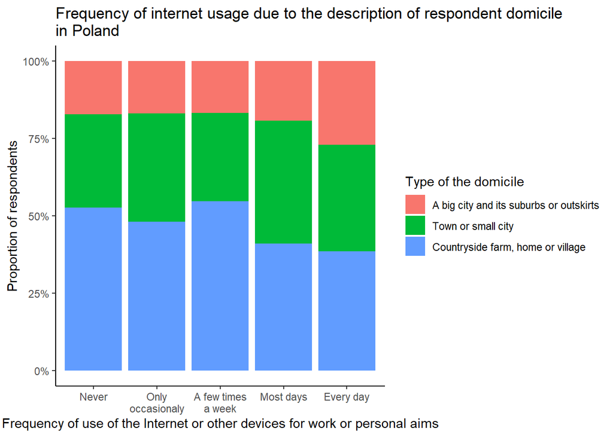

```r
ggplot(filter(ESS_NEW1, !is.na(netusoft), !is.na(domicil1)), aes(x = as.factor(netusoft), fill = as.factor(domicil1))) +
  geom_bar(position = "fill") +
  ggtitle('Frequency of internet usage due to the description of respondent domicile\nin Poland') +
  xlab('Frequency of use of the Internet or other devices for work or personal aims') +
  ylab('Proportion of respondents') +
  scale_x_discrete(labels = c('Never', 'Only\noccasionaly', 'A few times\na week', 'Most days', 'Every day')) +
  scale_y_continuous(labels = scales::percent_format()) +
  scale_fill_discrete(name = 'Type of the domicile', labels = c('A big city and its suburbs or outskirts', 'Town or small city', 'Countryside farm, home or village')) +
  theme_classic()
```

Step 3. Formulating research hypothesis.

H0 - there is no relation between the frequency of the usage of the Internet and other devices and type of domicile where a respondents live. Ha - there is a relation between the frequency of the usage of the Internet and other devices and type of domicile where a respondents live.

Step 4. Conducting Chi-squared test.

```r
chi.test <- chisq.test(Table_chi)
chi.test
```

```
##
##  Pearson's Chi-squared test
##
## data:  Table_chi
## X-squared = 34.701, df = 8, p-value = 3.03e-05
```

Conclusion. After conducting a chi-squared test we got a statistically significant p-value, since it is less than 0.01, which give us a strong basement for rejection the H0, that is frequency of the usage of the Internet and other devices and type of domicile where a respondents live is related between each other.

Step 5. Let’s take a look at the residuals.

```r
kable(chi.test$stdres)
```

|  | Never | Only occasionally | A few times a week | Most days | Every day |
| --- | --- | --- | --- | --- | --- |
| A big city and its suburbs or outskirts | -2.814797 | -1.4228031 | -1.692488 | -0.7201149 | 4.467442 |
| Town or small city | -1.399281 | 0.3970647 | -1.222858 | 1.2694170 | 1.148468 |
| Countryside farm, home or village | 3.694209 | 0.8206838 | 2.582817 | -0.5972375 | -4.846865 |

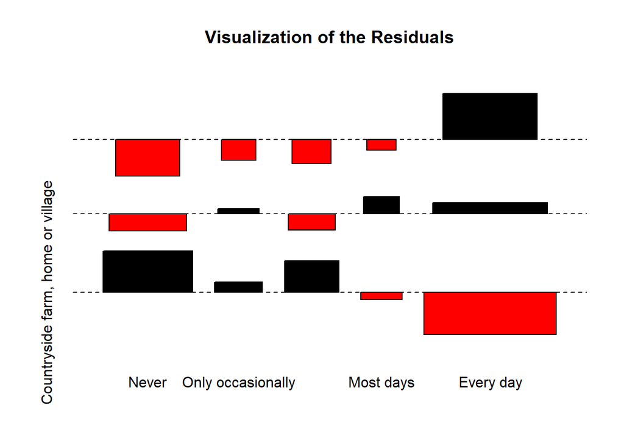

```r
assocplot(t(Table_chi), main = "Visualization of the Residuals" )
```

On this graph, in different places we can observe that the residuals have different values. There are much more residents of big city and its suburbs or outkirts who use Internet or other devices every day observed than expected. Inhabitans of Countryside farm, home or village make up the largest group of those who do not use the Internet at all observations of whom are also bigger than expected and also there is great negative residual for Every day group, so the number of observed countryside inhabitants who uses Internet daily is less than expected. Residents of towns and small cities are distributed approximately equally in the frequency of Internet use compared to others (but also the Most days has a bigger positive difference between observed and expected). This variation in group sizes indicates that the variables are not independent and once again confirms our previous conclusion that there is strong basement for rejecting the null hypothesis. Based on the test and on the plot illustrating the residuals we confirmed that there is a relation between a frequency of the usage of the Internet and other devices and type of domicile where a respondents live.

## T-Test

First of all, we should prepare data for t-test and explore it with the help of boxplot. There we need one numeric variable - ratio frequency of consuming (watching, reading, or listening) information about politics and current affairs - and nominal one - sex of a respondent.

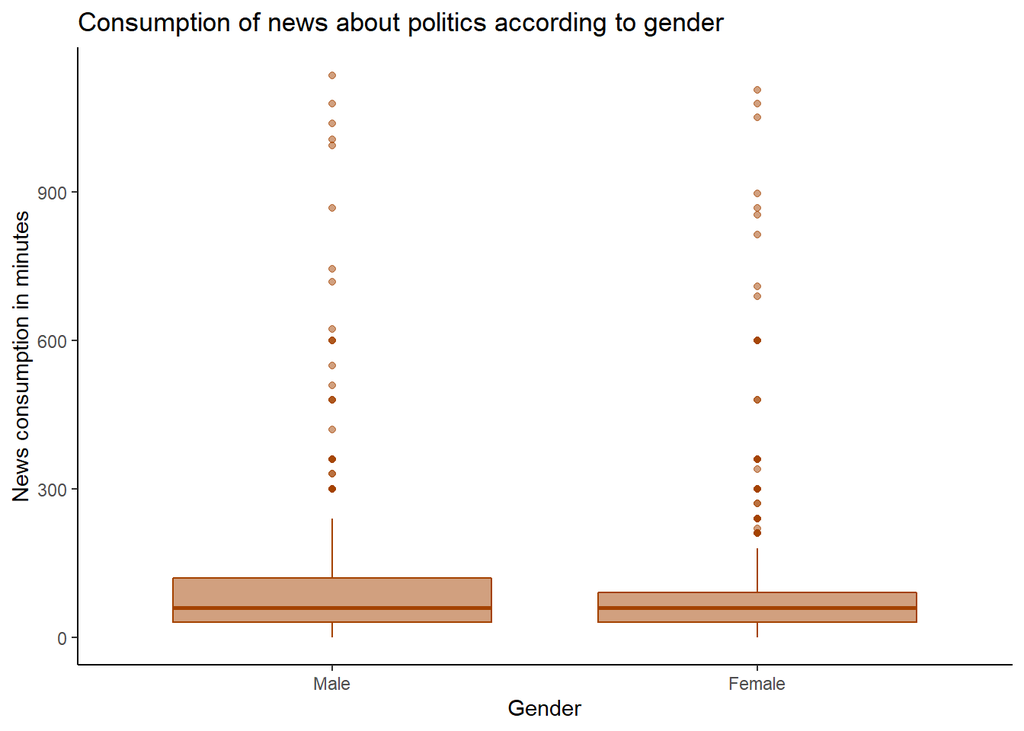

```r
ttest = dplyr::select(ESS9, gndr, nwspol)

ttest$gndr <- factor(ttest$gndr, labels = c("Male", "Female"), ordered = F, exclude = NA)

ggplot() +
  geom_boxplot(data = filter(ttest, !is.na(gndr), !is.na(nwspol)), aes(x = gndr, y = as.numeric(nwspol)), fill="#A44200", col="#A44200", alpha = 0.5) +
  xlab("Gender") +
  ylab("News consumption in minutes") +
  ggtitle("Consumption of news about politics according to gender") +
  theme_classic()
```

As we can see, the medians are visually equal, however, the range between the median and 3rd quartile is higher in male group as well as this group has taller whisker of maximum values. Moreover, both groups has a great amount of outliers of really big range - up to 1000 minutes of news consumption.

Next step is checking of normality. First way to do this is to check skewness and kurtosis.

```r
describeBy(ttest, ttest$gndr)
```

```
##
##  Descriptive statistics by group
## group: Male
##        vars   n  mean     sd median trimmed   mad min  max range skew kurtosis
## gndr*     1 710  1.00   0.00      1    1.00  0.00   1    1     0  NaN      NaN
## nwspol    2 695 94.98 129.09     60   70.82 44.48   0 1137  1137 4.35    25.23
##         se
## gndr*  0.0
## nwspol 4.9
## ------------------------------------------------------------
## group: Female
##        vars   n  mean     sd median trimmed   mad min  max range skew kurtosis
## gndr*     1 790  2.00   0.00      2    2.00  0.00   2    2     0  NaN      NaN
## nwspol    2 767 82.19 120.93     60   58.68 44.48   0 1107  1107 4.75    28.88
##          se
## gndr*  0.00
## nwspol 4.37
```

Skewness is a measure of the symmetry in a distribution. The normal distribution is symmetrical, so skew should be equal to 0 in normal distribution. Among males skewness is equal to 4,35, among females - 4,75. Moreover, both groups have high kurtosis values (it tells us, whether the distribution is peaked or plain): 25.23 for males and 28.88 for females - it means that the distribuions are longer with fatter tails (leptokurtic, but for normal mesokurtic distibution kurtosis should be equal to 3). Thus, the distribution of the first group (male) is less sharp than the distribution of the second group. The distribution is more symmetrical in the group of males, but still it is far away from normal. However, both of skews are greater than 1, so both of the groups have a high positive skewness (right).

Now let us draw a density plot to check the distribution.

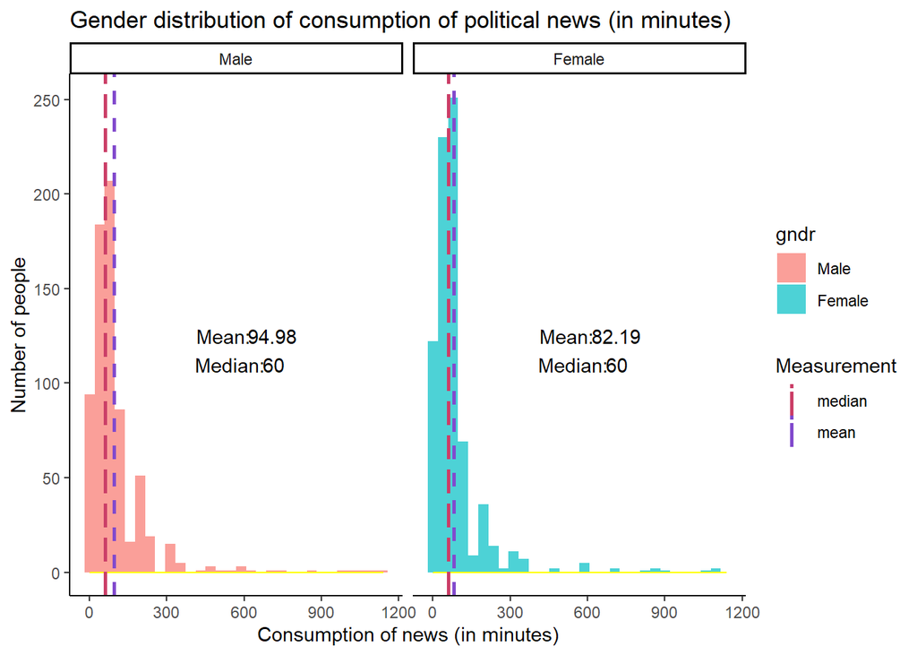

```r
ttest$nwspol = as.numeric(ttest$nwspol)
t = ttest %>% group_by(gndr) %>% dplyr::summarise(avg = mean(na.omit(nwspol)), med = median(na.omit(nwspol)))

ggplot(filter(ttest, !is.na(nwspol)), aes(x = nwspol, fill = gndr)) +
  geom_histogram(position = "identity", alpha = 0.7) +
  geom_density(col = "yellow", fill = "white", alpha = 0.1) +
  scale_color_manual(name = "Measurement", values = c(median = "#cb3f68", mean = "#824acd")) +
  xlab("Consumption of news (in minutes)") +
  ylab("Number of people") +
  ggtitle("Gender distribution of consumption of political news (in minutes)") +
  theme_classic() +
  facet_wrap(. ~ gndr) +
  geom_vline(data = t, aes(xintercept = avg, color = 'mean'), linetype = "dashed", size = 1) +
  geom_vline(data = t, aes(xintercept = med, color = 'median'), linetype = "longdash", size = 1) +
  geom_text(data = t, aes(x = 520, y = 125, label = "Mean:")) +
  geom_text(data = t, aes(x = 545, y = 110, label = "Median:")) +
  geom_text(data = t, aes(x = 710, y = 125, label = round(avg, 2))) +
  geom_text(data = t, aes(x = 715, y = 110, label = round(med, 2)))
```

We can conclude that both groups are really far from normal distribution

So, we claim that interest in politics depends on gender. To check our assumption we will conduct statistical test to highlight (or do not highlight) the correlation between gender and time (in minutes) spent on news about politics.

Conducting T-test:

H0: the mean time spent in political news (in minutes) of males and females does not differ. H1: the mean time does differ and, thus, there is a relation between gender and news consumption.

```r
t.test(ttest$nwspol ~ ttest$gndr)
```

```
##
##  Welch Two Sample t-test
##
## data:  ttest$nwspol by ttest$gndr
## t = 1.9499, df = 1421.9, p-value = 0.05139
## alternative hypothesis: true difference in means between group Male and group Female is not equal to 0
## 95 percent confidence interval:
##  -0.07726513 25.66229885
## sample estimates:
##   mean in group Male mean in group Female
##             94.98417             82.19166
```

Statistical conclusion: at the 5% significance level on the available data the null hypothesis should not be rejected in favor of the alternative one (p-value > 0.05). Substantive conclusion : there is no significant difference between males and females in consumption of political news. However, the means are different: males consume political news about 95 minutes a day on average and females only around 82 minutes a day.

Next step is to conduct non-parametric test to double-check the results

We have following hypotheses: H0: the two populations have the same distribution with the same median news consumption H1: the two populations have the different distribution with the different median news consumption

```r
wilcox.test(nwspol ~ gndr, data = ttest)
```

```
##
##  Wilcoxon rank sum test with continuity correction
##
## data:  nwspol by gndr
## W = 290902, p-value = 0.002235
## alternative hypothesis: true location shift is not equal to 0
```

Statistical conclusion: according to the obtained p-value, which is significant (0.002 which is less than 0.01), we have strong evidence to reject H0. Substantive conclusion: The Wilcoxon test says that the news consumption of people from the considered groups is significantly different among those males and females.

Overall, the results of test are different, but taking into account the abnormality of data distribution we can conclude that the result of wilcox test is more trustful. So, there is a connection between gender and political news assumption.

## ANOVA

For ANOVA test we chose one ratio and one nominal variables - there are frequency of Internet usage on usual day in minutes and marital status. It is important that marital status has more than 2 levels, so ANOVA is better applied there. Also, there are three assumptions to use parametric ANOVA test and one these is independence of observations which in our case is performed as the data was independently collected.

At first, we should take a look at how many observations do we have in our nominal variable.

```r
table(ESS_NEW1$marsts)
```

```
##
##   1   4   5   6
##  22  75 140 414
```

There we see that our first group (legally married Poles) has less than 30 observations. We could merge several groups into one, but they are too different in their meaning, so it would be absurd (first group stands for legally married and the second (4 in code) is for divorced, for example). So, here we decided to delete the first group at all and to use others in parametric ANOVA test.

Let’s create a new variable with 1 groups removed and others named

```r
ESS_NEW1$marital <- rep(NA, length(ESS_NEW1$marsts))

ESS_NEW1$marital[ESS_NEW1$marsts == 4] <- "Legally divorced or\nCivil union dissolved"
ESS_NEW1$marital[ESS_NEW1$marsts == 5] <- "Widowed or\nCivil partner died"
ESS_NEW1$marital[ESS_NEW1$marsts == 6] <- "Never married or\nin legally registered civil union"
```

Now let’s take a look at the distribution of a internet usage variable across marital status groups

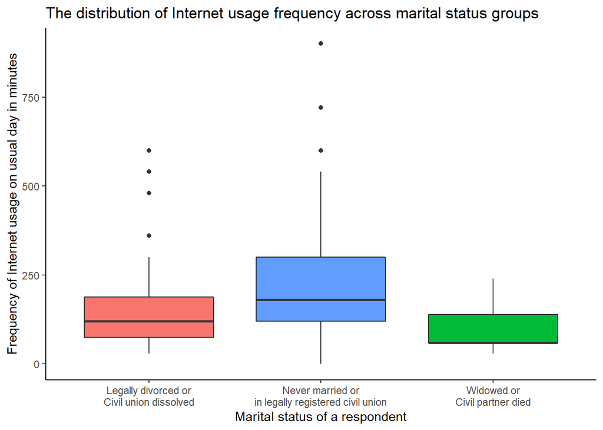

```r
ggplot(filter(ESS_NEW1, !is.na(marital), !is.na(netustm)), aes(as.factor(marital), as.numeric(netustm))) +
  geom_boxplot(aes(fill = as.factor(marsts))) +
  ggtitle("The distribution of Internet usage frequency across marital status groups") +
  xlab("Marital status of a respondent") +
  ylab("Frequency of Internet usage on usual day in minutes") +
  theme_classic() +
  theme(legend.position = "none")
```

So, we see the differences in medians, outliers and variances. Now, we check the next ANOVA assumption - equality of variances - with Levene’s test.

```r
leveneTest(ESS_NEW1$netustm ~ as.factor(ESS_NEW1$marital))
```

```
## Levene's Test for Homogeneity of Variance (center = median)
##        Df F value Pr(>F)
## group   2  2.0595 0.1289
##       390
```

The Levene’s Test indicated insignificant p-value of 0.1289, so the variances of groups are equal, further we will specify equal variances for F-test. Let’s use aov function which implies equal variances.

H0 - there is no difference in means of Internet usage between marital status groups. Ha - the difference in means of Internet usage between marital status groups is statistically significant.

```r
aov.out <- aov(as.numeric(ESS_NEW1$netustm) ~ as.factor(ESS_NEW1$marital))
summary(aov.out)
```

```
##                              Df  Sum Sq Mean Sq F value   Pr(>F)
## as.factor(ESS_NEW1$marital)   2  342124  171062   8.375 0.000275 ***
## Residuals                   390 7965647   20425
## ---
## Signif. codes:  0 '***' 0.001 '**' 0.01 '*' 0.05 '.' 0.1 ' ' 1
## 1107 пропущенных наблюдений удалены
```

P-value is less than 0.001, so the difference in means is statistically significant (H0 is rejected and Ha is accepted), so we conclude that there is statistically significant difference between the mean values of Internet Usage across Marital Status groups. The final assumption of parametric ANOVA test is normality of residuals. To check this we might create a Q-Q plot.

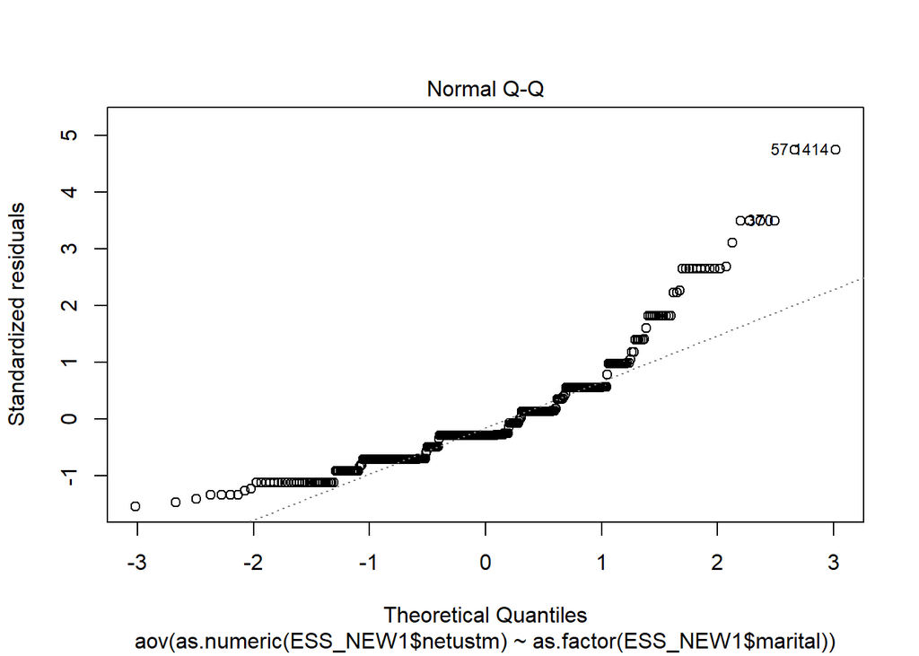

```r
plot(aov.out, 2)
```

As we see, the distributions of residuals is far from normal. However, let’s check it more formal way.

```r
anova.res <- residuals(object = aov.out)
describe(anova.res)
```

```
##    vars   n mean     sd median trimmed   mad     min    max range skew kurtosis
## X1    1 393    0 142.55 -41.15  -21.05 88.96 -221.15 678.85   900 1.69     3.68
##      se
## X1 7.19
```

There we see that kurtosis is bigger than 2, it says against the normality, but we might also use Shapiro-Wilk normality test.

```r
shapiro.test(x = anova.res)
```

```
##
##  Shapiro-Wilk normality test
##
## data:  anova.res
## W = 0.85233, p-value < 2.2e-16
```

The p-value is statistically significant (less than 0.01), so now we are sure that residuals distribution is not normal. Nevertheless this assumptions does not hold, let’s switch to post-hoc test. In our case of equal variances we use Tukey’s post hoc test.

H0 - there is no difference in means of Internet usage between two particular marital status groups. Ha - the difference in means of Internet usage between two particular marital status groups is statistically significant.

```r
TukeyHSD(aov.out)
```

```
##   Tukey multiple comparisons of means
##     95% family-wise confidence level
##
## Fit: aov(formula = as.numeric(ESS_NEW1$netustm) ~ as.factor(ESS_NEW1$marital))
##
## $`as.factor(ESS_NEW1$marital)`
##                                                                                                      diff
## Never married or\nin legally registered civil union-Legally divorced or\nCivil union dissolved   61.04387
## Widowed or\nCivil partner died-Legally divorced or\nCivil union dissolved                       -64.03274
## Widowed or\nCivil partner died-Never married or\nin legally registered civil union             -125.07661
##                                                                                                        lwr
## Never married or\nin legally registered civil union-Legally divorced or\nCivil union dissolved    9.112586
## Widowed or\nCivil partner died-Legally divorced or\nCivil union dissolved                      -166.163195
## Widowed or\nCivil partner died-Never married or\nin legally registered civil union             -216.820170
##                                                                                                      upr
## Never married or\nin legally registered civil union-Legally divorced or\nCivil union dissolved 112.97515
## Widowed or\nCivil partner died-Legally divorced or\nCivil union dissolved                       38.09772
## Widowed or\nCivil partner died-Never married or\nin legally registered civil union             -33.33304
##                                                                                                    p adj
## Never married or\nin legally registered civil union-Legally divorced or\nCivil union dissolved 0.0163677
## Widowed or\nCivil partner died-Legally divorced or\nCivil union dissolved                      0.3040395
## Widowed or\nCivil partner died-Never married or\nin legally registered civil union             0.0041308
```

There we see that p-value is lower than 0.05 in the first and than 0.01 in the third pair, so they are statistically significant (H0 is rejeted). On the other hand the difference between widowed and divorced is not significant with p-value of 0.3 (H0 is not rejected). Let’s check it by plot.

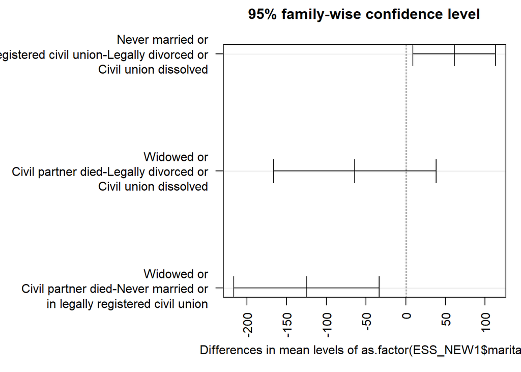

```r
par(mar = c(5, 15, 3, 1))
Tukey <- TukeyHSD(aov.out)
plot(Tukey, las = 2)
```

It is seen that the second pair crosses the 0 line, so it the difference in these two groups is not statistically significant. Now, it is time to calculate the effect size, omega-squared.

```r
anova_stats(aov.out)
```

```
## term                        |  df |     sumsq |    meansq | statistic | p.value | etasq | partial.etasq | omegasq | partial.omegasq | epsilonsq | cohens.f | power
## ------------------------------------------------------------------------------------------------------------------------------------------------------------------
## as.factor(ESS_NEW1$marital) |   2 | 3.421e+05 | 1.711e+05 |     8.375 |  < .001 | 0.041 |         0.041 |   0.036 |           0.036 |     0.036 |    0.207 | 0.964
## Residuals                   | 390 | 7.966e+06 | 20424.736 |           |         |       |               |         |                 |           |          |
```

The omega-squared is 0.036, it indicates that although the difference is statistically significant, the effect size is low.

Let’s check our conclusions with non-parametric ANOVA test - Kruskal-Wallis rank sum test - which does not imply assumptions (one of three did not hold for parametric ANOVA, so it is important to know non-parametric results).

H0 - there is no difference in means of Internet usage between marital status groups. Ha - the difference in means of Internet usage between marital status groups is statistically significant.

```r
kruskal.test(as.numeric(netustm) ~ as.factor(marital), data = ESS_NEW1)
```

```
##
##  Kruskal-Wallis rank sum test
##
## data:  as.numeric(netustm) by as.factor(marital)
## Kruskal-Wallis chi-squared = 27.157, df = 2, p-value = 1.267e-06
```

It resulted in low p-value, so confirming our previous conclusions about statistically significant differences in means across groups. As this test is significant, we might use non-parametric post hoc Dunn’s test.

H0 - there is no difference in means of Internet usage between two particular marital status groups. Ha - the difference in means of Internet usage between two particular marital status groups is statistically significant.

```r
DunnTest(as.numeric(netustm) ~ as.factor(marital), data = ESS_NEW1)
```

```
##
##  Dunn's test of multiple comparisons using rank sums : holm
##
##                                                                                                mean.rank.diff
## Never married or\nin legally registered civil union-Legally divorced or\nCivil union dissolved       62.44250
## Widowed or\nCivil partner died-Legally divorced or\nCivil union dissolved                           -61.34375
## Widowed or\nCivil partner died-Never married or\nin legally registered civil union                 -123.78625
##                                                                                                   pval
## Never married or\nin legally registered civil union-Legally divorced or\nCivil union dissolved 0.00067
## Widowed or\nCivil partner died-Legally divorced or\nCivil union dissolved                      0.07306
## Widowed or\nCivil partner died-Never married or\nin legally registered civil union             0.00017
##
## Never married or\nin legally registered civil union-Legally divorced or\nCivil union dissolved ***
## Widowed or\nCivil partner died-Legally divorced or\nCivil union dissolved                      .
## Widowed or\nCivil partner died-Never married or\nin legally registered civil union             ***
## ---
## Signif. codes:  0 '***' 0.001 '**' 0.01 '*' 0.05 '.' 0.1 ' ' 1
```

It resulted again that only one pair of widowed and divorced does not have significant differences in their medians as the p-value is high. Other two pairs have low p-value and statistically significant differences confirming our previous Tukey’s post hoc test.

All in all, the difference between means of Internet usage frequency among different marital status groups is statistically significant, however, the effect size is low, and there is one pair of three with not statistically significant difference.

# Project III

## Introduction

Hello! This is our team ΔУРКА again, which members are: Anastasia Gorokhova, Denis Kapitonov, Kirill Mukhin, and Fedor Shvets presenting you our project on topic ‘Media and Social Trust’. In this project, we will explore correlations and create linear regression models. Each of us contributed to a particular part of this project:

- Mukhin Kirill - data exploration (constructing different types of graphs with all their description); providing a summary and its description for the best regression model; statements about regression assumptions compliance; general conclusions based on the final table.
- Shvets Fedor - constructing a correlation matrix with its description; constructing the first regression model with its description; regression equation with all coefficients and conclusions based on this equation; general conclusions based on the final table.
- Kapitonov Denis - data selection; variables description for correlation; constructing table; recoding variables; searching the literature for hypotheses; providing a summary and its description for the best regression model;
- Gorokhova Anastasia - constructing the second and the third regression model with their description; comparing all models with the conclusion; linear regression assumptions check.

## Data Selection

For the purposes of further analysis we create a new dataset containing only five variables we will need.

```r
ESS_NEW2 = ESS9 %>% select(netustm, rlgdgr, grspnum, agea, isco08)
str(ESS_NEW2)
```

```
## tibble [1,500 x 5] (S3: tbl_df/tbl/data.frame)
##  $ netustm: dbl+lbl [1:1500]  60, 120, 180,  NA, 180,  NA,  90, 150,  NA,  NA,  60...
##    ..@ label        : chr "Internet use, how much time on typical day, in minutes"
##    ..@ format.spss  : chr "F4.0"
##    ..@ display_width: int 9
##    ..@ labels       : Named num [1:4] 6666 7777 8888 9999
##    .. ..- attr(*, "names")= chr [1:4] "Not applicable" "Refusal" "Don't know" "No answer"
##  $ rlgdgr : dbl+lbl [1:1500]  8,  5,  1,  9,  0,  7,  7,  3,  5,  8,  7,  8,  0,  ...
##    ..@ label      : chr "How religious are you"
##    ..@ format.spss: chr "F2.0"
##    ..@ labels     : Named num [1:14] 0 1 2 3 4 5 6 7 8 9 ...
##    .. ..- attr(*, "names")= chr [1:14] "Not at all religious" "1" "2" "3" ...
##  $ grspnum: dbl+lbl [1:1500] 1640,   NA, 2800,   NA, 5000,   NA,   NA,   NA,   NA,...
##    ..@ label        : chr "What is your usual [weekly/monthly/annual] gross pay"
##    ..@ format.spss  : chr "F9.0"
##    ..@ display_width: int 11
##    ..@ labels       : Named num [1:4] 6.67e+08 7.78e+08 8.89e+08 1.00e+09
##    .. ..- attr(*, "names")= chr [1:4] "Not applicable" "Refusal" "Don't know" "No answer"
##  $ agea   : dbl+lbl [1:1500] 37, 23, 22, 83, 36, 32, 29, 72, 45, 63, 33, 51, 27, 7...
##    ..@ label        : chr "Age of respondent, calculated"
##    ..@ format.spss  : chr "F4.0"
##    ..@ display_width: int 6
##    ..@ labels       : Named num 999
##    .. ..- attr(*, "names")= chr "Not available"
##  $ isco08 : dbl+lbl [1:1500] 4211, 7120, 9629, 9112, 3123, 3112, 2341, 3334, 9329,...
##    ..@ label      : chr "Occupation, ISCO08"
##    ..@ format.spss: chr "F5.0"
##    ..@ labels     : Named num [1:594] 0 100 110 200 210 300 310 1000 1100 1110 ...
##    .. ..- attr(*, "names")= chr [1:594] "Armed forces occupations" "Commissioned armed forces officers" "Commissioned armed forces officers" "Non-commissioned armed forces officers" ...
```

## Variables Description for Correlation

As we are studying the topic ‘Media & Social Trust’ we chose one variable from this section as the outcome - frequency of Internet usage on a typical day. We suppose that nowadays Internet combines a lot of purposes of usage such as entertainment, news reading, chatting etc. Thus, it is important part of our lives and we found it interesting to explore which variables are correlated with this one.

As the predictor variables we chose three continuous ones:

- Age. We assume that older people will use Internet much less than the younger ones as they are used to a different way of life, without using such tools and do not use them as often as younger people. As can be seen from the statistics[1], younger people use Internet more often, so we want to check if our results will be the same. Thus, we expect that age will be negatively correlated with frequency of Internet usage with at least medium corr. coefficient.
- Gross Pay. We consider this variable as an indicator of person’s SES, so that people with higher pay will use Internet more frequently. As it is found in the research[2], SES can be associated with Internet usage, so we expect that it will be also positively correlated with gross pay in our data. We assume that the coefficient will be around 0.3.
- Religiosity. This variable might be negatively associated with Internet usage as it is told in the research of Greg G. Armfield & R. Lance Holbert[3]. We want to check if the findings of that paper will be the same as ours. Moreover, we know that Poland is religious country[4], so the corr. coefficient is expected to be high.

Also we chose one categorical variable as a predictor, which we will use in one of the regression models

- Occupation. As we already mentioned it, C.Wangberg’s et al. research gives us a good example of measuring relation between SES and internet use[2]. And as we know from theory, occupation is a good indicator of SES: It tells us more than the same gross pay and that is why this variable was chosen. We expect that relationships will be stronger compared to gross pay predictor as well as there will be a negative trend in Internet usage as we move from the first large occupational groups (Managers and Professionals) to the last (Elementary occupations).

We put forward a research question: Which of our chosen variables predict the frequency of Internet use on typical day in Poland in the better way.

We also formulate research hypotheses:

Null hypotheses (H0):

- There is no relation between age and frequency of Internet usage.
- There is no relation between gross pay and frequency of Internet usage.
- There is no relation between religiosity and frequency of Internet usage.
- There is no relation between occupation and frequency of Internet usage.

Alternative hypotheses (Ha):

- There is relation between age and frequency of Internet usage.
- There is relation between gross pay and frequency of Internet usage.
- There is relation between religiosity and frequency of Internet usage.
- There is relation between occupation and frequency of Internet usage.

In order to describe variables we have, we create four vectors with original names, description, variable types and values range.

```r
Variable_Name = c('netustm', 'rlgdgr', 'grspnum', 'agea', 'isco08')

Description = c('Frequency of Internet usage', 'Religiosity of respondent', 'Usual (weekly/monthly/annual) gross pay of respondent', 'Age of respondent', 'Occupation')

Variable_Type = c('Ratio', 'Interval', 'Ratio', 'Ratio', 'Nominal')

Measurement <- c('0-900', '0-10', '0-500000', '15-87', 'Occupational groups coded by ISCO-08 with range from 110 to 9629')
```

Further, we combine these vectors in a data frame to provide more convenient way of representation.

```r
data_description <- data.frame(Variable_Name, Description, Variable_Type, Measurement, stringsAsFactors = FALSE)

kable(data_description) %>%
  kable_styling(bootstrap_options = c('bordered'), full_width = FALSE)
```

| Variable_Name | Description | Variable_Type | Measurement |
| --- | --- | --- | --- |
| netustm | Frequency of Internet usage | Ratio | 0-900 |
| rlgdgr | Religiosity of respondent | Interval | 0-10 |
| grspnum | Usual (weekly/monthly/annual) gross pay of respondent | Ratio | 0-500000 |
| agea | Age of respondent | Ratio | 15-87 |
| isco08 | Occupation | Nominal | Occupational groups coded by ISCO-08 with range from 110 to 9629 |

As we saw from str() function above, all variables are of haven_labelled class. Let’s convert them into needed numeric for continuos variables and factor for categorical one.

```r
ESS_NEW2$netustm = as.numeric(as.character(ESS_NEW2$netustm))
ESS_NEW2$rlgdgr = as.numeric(as.character(ESS_NEW2$rlgdgr))
ESS_NEW2$grspnum = as.numeric(as.character(ESS_NEW2$grspnum))
ESS_NEW2$agea = as.numeric(as.character(ESS_NEW2$agea))
ESS_NEW2$isco08 = as.factor(ESS_NEW2$isco08)
```

Let’s check if there are values coded as ‘Refusal’, ‘Don’t Know’ etc. They are large values like 6666, 7777 or 8888.

```r
table(ESS_NEW2$netustm)
```

```
##
##   0  10  15  20  30  40  45  50  60  65  80  90  95 100 105 120 135 140 145 150
##   3   1   3   3  42   3   7   2 145   1   2  52   1   2   1 161   2   1   1  25
## 155 165 170 180 200 210 215 220 225 240 255 270 285 300 330 360 390 420 450 480
##   1   1   1 130   2  18   1   1   1  69   1  10   1  53   1  30   3  11   1  24
## 540 600 720 900
##   7  17   7   4
```

```r
table(ESS_NEW2$rlgdgr)
```

```
##
##   0   1   2   3   4   5   6   7   8   9  10
##  84  33  51  78  72 245 185 227 236 100 163
```

```r
table(ESS_NEW2$grspnum)
```

```
##
##      0    250    300    500    600    620    650    700    900   1000   1100
##     11      1      2      2      1      1      1      1      1      4      1
##   1200   1300   1400   1500   1600   1640   1700   1800   1900   2000   2100
##      1      1      1      3      1      1      1      3      3     13     18
##   2200   2220   2250   2300   2350   2370   2390   2400   2450   2480   2500
##     21      1      3     12      1      1      1      9      1      1     29
##   2550   2600   2700   2800   2880   2900   3000   3100   3200   3270   3300
##      1     12      6     11      1      6     31      3     11      1      4
##   3360   3400   3500   3600   3667   3700   3800   3900   4000   4100   4200
##      1      6     22      9      1     11      2      1     19      2      3
##   4300   4400   4500   4600   4700   4800   5000   5200   5300   5400   5500
##      7      2     10      3      2      1     27      3      1      1      3
##   5600   5800   6000   6400   6500   7000   7200   7300   7500   8000   8500
##      1      1     10      1      4     11      1      1      1      4      2
##   9000   9500   9700  10000  11000  12000  13000  15000  16000  18000  20000
##      2      1      1      5      1      2      2      2      1      1      1
##  25000  28000  28600  30000  40000  50000 120000  5e+05
##      1      2      1      2      1      2      1      1
```

```r
table(ESS_NEW2$agea)
```

```
##
## 15 16 17 18 19 20 21 22 23 24 25 26 27 28 29 30 31 32 33 34 35 36 37 38 39 40
## 12 21 23 23 21 22 16 22 22 22 22 23 24 25 18 18 31 20 24 35 25 25 28 30 28 28
## 41 42 43 44 45 46 47 48 49 50 51 52 53 54 55 56 57 58 59 60 61 62 63 64 65 66
## 25 30 21 23 20 17 22 22 21 15 18 27 14 21 21 24 18 21 21 31 27 35 31 27 24 33
## 67 68 69 70 71 72 73 74 75 76 77 78 79 80 81 82 83 84 85 86 87
## 23 26 21 25 19 18 16  9 11  9 13 12  8 17 11 12  9 12  5  6  1
```

```r
table(ESS_NEW2$isco08)
```

```
##
##  110  210  310 1113 1120 1200 1210 1211 1212 1213 1221 1222 1223 1300 1311 1321
##    4    2    1    1    6    1    1   11    6    6    6    7    2    1    2   25
## 1322 1323 1324 1330 1341 1342 1345 1346 1349 1411 1412 1420 1430 1439 2100 2113
##    3   13   21    5    1    2    6    5    2    2    7   17    5    4    1    1
## 2131 2141 2142 2143 2144 2145 2149 2152 2164 2211 2212 2221 2222 2261 2263 2264
##    1    7    9    1    4    1    2    2    1    1    2    4    2    4    1    2
## 2265 2267 2269 2310 2320 2330 2341 2342 2352 2353 2359 2411 2412 2413 2420 2421
##    4    2    1    2    1    8   33    4    2    1    4   20    5    5    5    5
## 2422 2430 2431 2433 2500 2510 2512 2514 2522 2610 2611 2621 2634 2635 2636 2643
##    1    1    2    5    1    2    2    2    2    1    5    1    2    1    1    1
## 2651 2652 2654 3112 3113 3114 3115 3117 3118 3119 3121 3122 3123 3131 3132 3135
##    2    3    1   10    7    1   16    2    1    3    4   16    4    4    1    1
## 3139 3211 3212 3213 3214 3221 3251 3255 3312 3313 3314 3321 3322 3323 3332 3333
##    1    1    2    1    1    7    1    1    2   28    3    1    9    2    1    5
```

[output cut: 20 more lines]

As we see, there are no such values, so that we must remove all NAs in the dataset to have only observations having all of the variables.

```r
ESS_NEW2 = na.omit(ESS_NEW2)
```

## Data Exploration

Let’s have a look at the summary of the chosen variables.

```r
summary(ESS_NEW2)
```

```
##     netustm          rlgdgr          grspnum            agea
##  Min.   :  0.0   Min.   : 0.000   Min.   :     0   Min.   :18.00
##  1st Qu.: 90.0   1st Qu.: 3.000   1st Qu.:  2500   1st Qu.:29.75
##  Median :120.0   Median : 6.000   Median :  3400   Median :37.00
##  Mean   :191.6   Mean   : 5.199   Mean   :  6457   Mean   :38.01
##  3rd Qu.:240.0   3rd Qu.: 7.000   3rd Qu.:  5000   3rd Qu.:45.25
##  Max.   :900.0   Max.   :10.000   Max.   :500000   Max.   :69.00
##
##      isco08
##  5223   : 21
##  2341   : 13
##  5230   : 12
##  8332   :  8
##  1321   :  7
##  6130   :  7
##  (Other):244
```

Now let’s visualize the variables outliers. For make grspnum boxplot understandable (there is really huge outlier), we log the y axis.

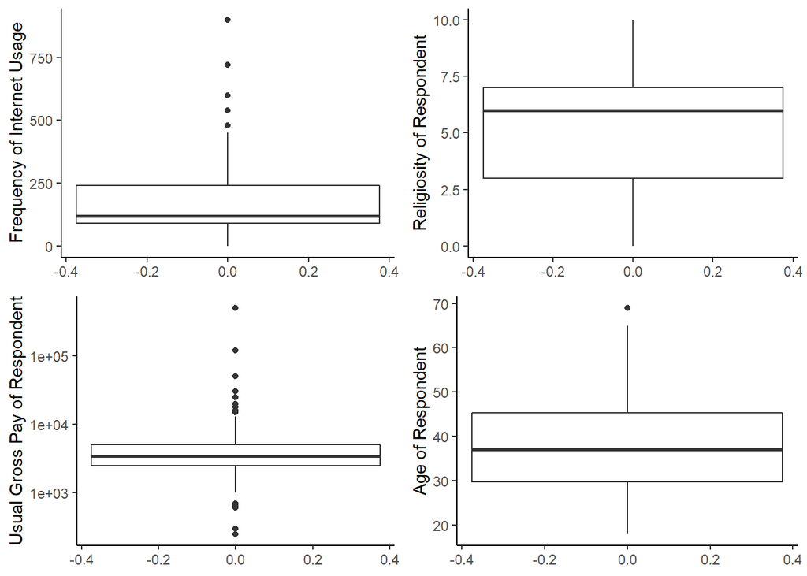

```r
a = ggplot(ESS_NEW2, aes(y = netustm)) +
  geom_boxplot() +
  ylab("Frequency of Internet Usage") +
  theme_classic()

b = ggplot(ESS_NEW2, aes(y = rlgdgr)) +
  geom_boxplot() +
  ylab("Religiosity of Respondent") +
  theme_classic()

c = ggplot(ESS_NEW2, aes(y = grspnum)) +
  geom_boxplot() +
  ylab("Usual Gross Pay of Respondent") +
  scale_y_log10() +
  theme_classic()

d = ggplot(ESS_NEW2, aes(y = agea)) +
  geom_boxplot() +
  ylab("Age of Respondent") +
  theme_classic()

grid.arrange(a, b, c, d, ncol = 2)
```

Now we’re visualizing the distributions of variables with histograms (x axis of grspnum is again log due to huge outlier).

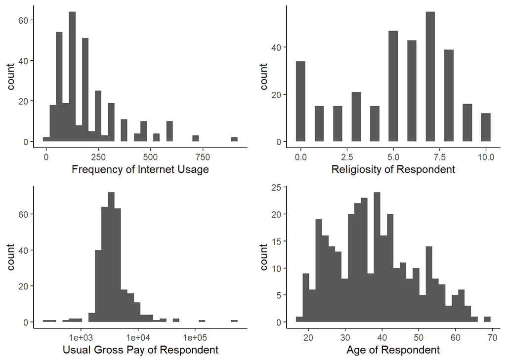

```r
e = ggplot(data = ESS_NEW2, aes(x = netustm)) +
  geom_histogram() +
  xlab("Frequency of Internet Usage") +
  theme_classic()

f = ggplot(data = ESS_NEW2, aes(x = rlgdgr)) +
  geom_histogram(binwidth = 0.5) +
  xlab("Religiosity of Respondent") +
  theme_classic()

g = ggplot(data = ESS_NEW2, aes(x = grspnum)) +
  geom_histogram() +
  xlab("Usual Gross Pay of Respondent") +
  scale_x_log10() +
  theme_classic()

h = ggplot(data = ESS_NEW2, aes(x = agea)) +
  geom_histogram() +
  xlab("Age of Respondent") +
  theme_classic()

grid.arrange(e, f, g, h, ncol = 2)
```

These histograms confirms that all variables have non normal distribution.

Now let’s switch to categorical variable and examine it with barplot. At first, let’s combine all ocupations in groups. We chose categories based on the following logic: there are a lot of occupations, which could be merged into larger groups. These groups could be identified from the first digit of the ISCO-08 code (in our case, four-digit occupations which code starts from 1 are related to Managers and so on). Thus, we merge all the occupations into 9 big groups:

```r
ESS_NEW2 = ESS_NEW2 %>% filter(ESS_NEW2$isco08 != "110" & ESS_NEW2$isco08 != "210" & ESS_NEW2$isco08 != "310")
ESS_NEW2$isco08 = substring(ESS_NEW2$isco08, 1, 1)
table(ESS_NEW2$isco08)
```

```
##
##  1  2  3  4  5  6  7  8  9
## 47 67 42 24 64 10 29 24  5
```

```r
ESS_NEW2$isco08 = as.factor(ESS_NEW2$isco08)
levels(ESS_NEW2$isco08)[1] <- "Managers"
levels(ESS_NEW2$isco08)[2] <- "Professionals"
levels(ESS_NEW2$isco08)[3] <- "Technicians and associate professionals"
levels(ESS_NEW2$isco08)[4] <- "Clerical support workers"
levels(ESS_NEW2$isco08)[5] <- "Service and sales workers"
levels(ESS_NEW2$isco08)[6] <- "Skilled agricultural, forestry and fishery workers"
levels(ESS_NEW2$isco08)[7] <- "Craft and related trades workers"
levels(ESS_NEW2$isco08)[8] <- "Plant and machine operators, and assemblers"
levels(ESS_NEW2$isco08)[9] <- "Elementary occupations"
```

Then we can make a barplot to show visually how many observations are in the particular occupational group.

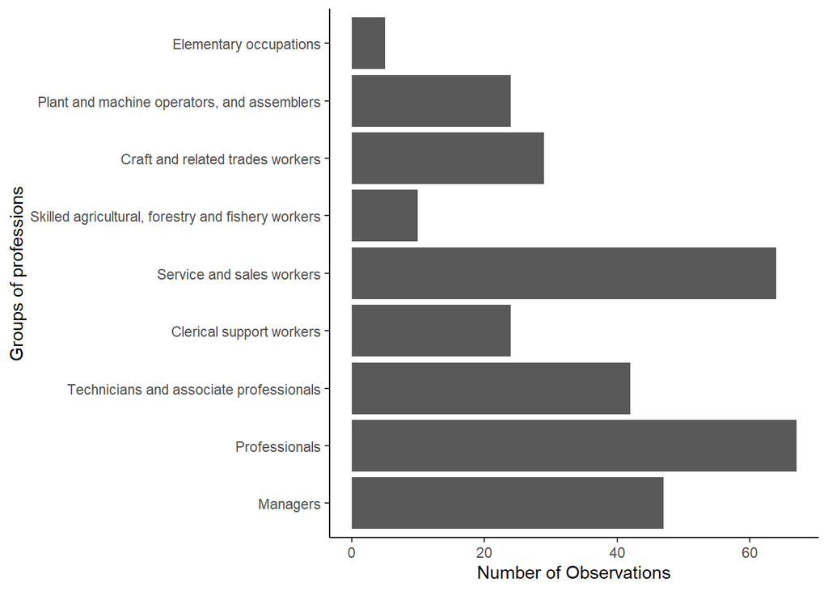

```r
ggplot(ESS_NEW2, aes(x = isco08)) +
  geom_bar() +
  xlab("Groups of professions") +
  ylab("Number of Observations") +
  coord_flip() +
  theme_classic()
```

Based on this barplot we can clearly see that all groups are different in size. We also see that in Poland (at least in our cleared dataset), the most popular professions (having the greatest amount of observations) belong to the categories “Professionals” and “Service and sales workers”, at the same time the less wide-spread occupations belong to the “Elementary occupations” and “Skilled agricultural, forestry and fishery workers” categories.

Now we can construct scatterplots to see how the continuous variables are really correlated to the outcome (again, grspnum x scale is log).

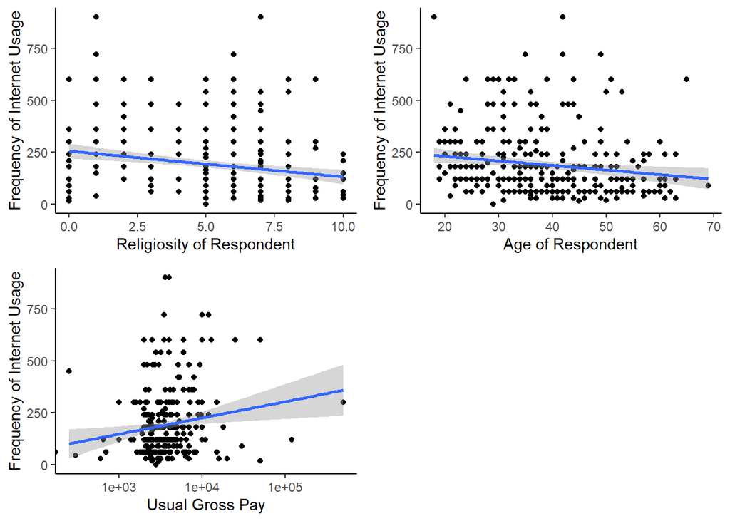

```r
i = ggplot(data = ESS_NEW2, aes(x = rlgdgr, y = netustm)) +
  geom_point() +
  geom_smooth(method = "lm") +
  xlab("Religiosity of Respondent") +
  ylab("Frequency of Internet Usage") +
  theme_classic()

j = ggplot(data = ESS_NEW2, aes(x = agea, y = netustm)) +
  geom_point() +
  geom_smooth(method = "lm") +
  xlab("Age of Respondent") +
  ylab("Frequency of Internet Usage") +
  theme_classic()

k = ggplot(data = ESS_NEW2, aes(x = grspnum, y = netustm)) +
  geom_point() +
  geom_smooth(method = "lm") +
  xlab("Usual Gross Pay") +
  ylab("Frequency of Internet Usage") +
  scale_x_log10() +
  theme_classic()

grid.arrange(i, j, k, ncol = 2)
```

These scatterplots show us that there is a positive correlation between Usual gross pay and Frequency of Internet usage (the slope is visually big but we think this is so because of outliers). Also, there is a negative correlation between Religiosity of respondent & Frequency of Internet usage and Age of respondent & Frequency of Internet usage. The slope seems to be low.

## Correlation Matrix

So, now we construct a correlation matrix in order to find out the highest (significant) coefficients between our variables. As our variables are distributed non normally, we use spearman method.

```r
tab_corr(ESS_NEW2[,1:4], corr.method = "spearman")
```

|  | netustm | rlgdgr | grspnum | agea |
| --- | --- | --- | --- | --- |
| netustm |  | -0.273*** | 0.117* | -0.243*** |
| rlgdgr | -0.273*** |  | -0.174** | 0.124* |
| grspnum | 0.117* | -0.174** |  | 0.253*** |
| agea | -0.243*** | 0.124* | 0.253*** |  |
| Computed correlation used spearman-method with listwise-deletion. |  |  |  |  |

On this matrix we can see a lot of coefficients, but we only interested in the highest coefficients. So, the highest correlation coefficient in this matrix is -0.273 (although it indicates low correlation). It represents the relation between Frequency of Internet usage and Religiosity of respondent. So, we will use this predictor as a basis on our regression models. But firstly we’ll check the significance of correlation with p-value.

```r
cor.test(ESS_NEW2$netustm, ESS_NEW2$rlgdgr, method = "spearman")
```

```
##
##  Spearman's rank correlation rho
##
## data:  ESS_NEW2$netustm and ESS_NEW2$rlgdgr
## S = 6446193, p-value = 9.332e-07
## alternative hypothesis: true rho is not equal to 0
## sample estimates:
##        rho
## -0.2734891
```

As we see from the output, the p-value is less than 0.01, so the correlation is statistically significant.

## Linear Regression Models

Now, we will construct the first regression model with only one predictor to find out how the frequency of Internet usage on typical day can be predicted by a person’s degree of religiosity.

```r
m1 <- lm(netustm ~ rlgdgr, data = ESS_NEW2)
tab_model(m1)
```

|  | netustm |  |  |
| --- | --- | --- | --- |
| Predictors | Estimates | CI | p |
| (Intercept) | 256.06 | 220.21 – 291.90 | **<0.001** |
| rlgdgr | -12.39 | -18.46 – -6.33 | **<0.001** |
| Observations | 312 |  |  |
| R<sup>2</sup> / R<sup>2</sup> adjusted | 0.050 / 0.047 |  |  |

So, we can see that P-value is less than 0.01 and thus the predicition is statistically significant. R-squared = 0.050 and Adjusted R-squared = 0.047, so that there is only 4.7% of variation in the frequency of Internet usage on typical day that can be explained by this model, which indicates the low level of predictive power (is can be compared with correlation coefficient as it indicates low correlation and thus we have low predictive power). The regression coefficient is equal to the -12.39, while the correlation coefficient is equal to the -0.273, so the outcome gradually decreases while predictor increases. As we can see both the regression model and correlation matrix show the negative relation between variables.

The next step is constructing model with two predictors by adding continuous variable, which, in theory, will help predict better the frequency of Internet usage on typical day - we chose the age as it has respectively high correlation coefficient (-0.243). But at first we should change the “agea” variable to make it start from 0, so that we will be able to interpret intercept value.

```r
ESS_NEW2$agea_st = ESS_NEW2$agea - 18
table(ESS_NEW2$agea_st)
```

```
##
##  0  1  2  3  4  5  6  7  8  9 10 11 12 13 14 15 16 17 18 19 20 21 22 23 24 25
##  1  4  5  6 10  9  9  7  6  8  8  5  8 14  6 10 12  8 15  9 11 13  8  8 12  8
## 26 27 28 29 30 31 32 33 34 35 36 37 38 39 40 41 42 43 44 45 47 51
## 10  4  7  2  6  6  4  5 10  4  4  4  2  5  3  1  4  5  1  3  1  1
```

Now we are ready to create the second model.

```r
m2 <- lm(netustm ~ rlgdgr + agea_st, data = ESS_NEW2)
tab_model(m2)
```

|  | netustm |  |  |
| --- | --- | --- | --- |
| Predictors | Estimates | CI | p |
| (Intercept) | 290.25 | 245.68 – 334.82 | **<0.001** |
| rlgdgr | -11.61 | -17.65 – -5.57 | **<0.001** |
| agea_st | -1.91 | -3.42 – -0.41 | **0.013** |
| Observations | 312 |  |  |
| R<sup>2</sup> / R<sup>2</sup> adjusted | 0.069 / 0.062 |  |  |

As we can see, the agea_st variable is close to a significant level, since p-value is 0.013 which is approximately equal to 0.01. Next, we construct the third model by adding another variable, which is catigorical for the same purpose.

```r
m3 <- lm(netustm ~ rlgdgr + agea_st + isco08, data = ESS_NEW2)
tab_model(m3)
```

|  | netustm |  |  |
| --- | --- | --- | --- |
| Predictors | Estimates | CI | p |
| (Intercept) | 356.20 | 295.09 – 417.30 | **<0.001** |
| rlgdgr | -11.17 | -17.16 – -5.18 | **<0.001** |
| agea_st | -2.73 | -4.26 – -1.20 | **0.001** |
| isco08 [Professionals] | -13.95 | -69.80 – 41.89 | 0.623 |
| isco08 [Technicians and associate professionals] | -40.11 | -102.56 – 22.34 | 0.207 |
| isco08 [Clerical support workers] | -40.50 | -114.68 – 33.69 | 0.284 |
| isco08 [Service and sales workers] | -82.33 | -139.61 – -25.04 | **0.005** |
| isco08 [Skilled agricultural, forestry and fishery workers] | -63.44 | -166.29 – 39.41 | 0.226 |
| isco08 [Craft and related trades workers] | -102.76 | -172.96 – -32.55 | **0.004** |
| isco08 [Plant and machine operators, and assemblers] | -129.12 | -202.89 – -55.36 | **0.001** |
| isco08 [Elementary occupations] | -122.40 | -260.58 – 15.78 | 0.082 |
| Observations | 312 |  |  |
| R<sup>2</sup> / R<sup>2</sup> adjusted | 0.135 / 0.106 |  |  |

We can see that three levels of categorical predictors have significant p-value (less than 0.01), while other categories have insignificant p-value (from 0.082 to 0.623). Also, the change in p-value for agea_st variable can be noticed - now it has the significant 0.001 value.

After that, we compare all models in order to find the best model, which is fits better than others. To do this we use ANOVA function.

```r
anova(m1, m2, m3)
```

```
## Analysis of Variance Table
##
## Model 1: netustm ~ rlgdgr
## Model 2: netustm ~ rlgdgr + agea_st
## Model 3: netustm ~ rlgdgr + agea_st + isco08
##   Res.Df     RSS Df Sum of Sq      F   Pr(>F)
## 1    310 7299734
## 2    309 7154681  1    145053 6.5700 0.010857 *
## 3    301 6645544  8    509137 2.8826 0.004164 **
## ---
## Signif. codes:  0 '***' 0.001 '**' 0.01 '*' 0.05 '.' 0.1 ' ' 1
```

We will make a conclusion about which model is the best based on the value of F-ratio.

So, we can see that the third model fits better than others. In detail, the second model predicts the outcome of Frequency of Internet usage better than the first model, because the p-value of the second model is really close to statistically significant indicator (around 0.01). However, the third model also has significant p-value, which is less then 0.01, so that the third model predicts the outcome better than the second. This means that we will continue to work with the third model.

Now we can provide summary of the chosen model.

```r
summary(m3)
```

```
##
## Call:
## lm(formula = netustm ~ rlgdgr + agea_st + isco08, data = ESS_NEW2)
##
## Residuals:
##     Min      1Q  Median      3Q     Max
## -263.41  -93.81  -37.21   57.84  704.34
##
## Coefficients:
##                                                           Estimate Std. Error
## (Intercept)                                               356.1950    31.0488
## rlgdgr                                                    -11.1728     3.0442
## agea_st                                                    -2.7299     0.7797
## isco08Professionals                                       -13.9550    28.3769
## isco08Technicians and associate professionals             -40.1110    31.7352
## isco08Clerical support workers                            -40.4953    37.6978
## isco08Service and sales workers                           -82.3260    29.1086
## isco08Skilled agricultural, forestry and fishery workers  -63.4372    52.2647
## isco08Craft and related trades workers                   -102.7553    35.6773
## isco08Plant and machine operators, and assemblers        -129.1235    37.4846
## isco08Elementary occupations                             -122.4029    70.2169
##                                                          t value Pr(>|t|)
## (Intercept)                                               11.472  < 2e-16 ***
## rlgdgr                                                    -3.670 0.000287 ***
## agea_st                                                   -3.501 0.000533 ***
## isco08Professionals                                       -0.492 0.623239
## isco08Technicians and associate professionals             -1.264 0.207234
## isco08Clerical support workers                            -1.074 0.283590
## isco08Service and sales workers                           -2.828 0.004995 **
## isco08Skilled agricultural, forestry and fishery workers  -1.214 0.225788
## isco08Craft and related trades workers                    -2.880 0.004260 **
## isco08Plant and machine operators, and assemblers         -3.445 0.000653 ***
## isco08Elementary occupations                              -1.743 0.082318 .
## ---
## Signif. codes:  0 '***' 0.001 '**' 0.01 '*' 0.05 '.' 0.1 ' ' 1
##
## Residual standard error: 148.6 on 301 degrees of freedom
## Multiple R-squared:  0.1348, Adjusted R-squared:  0.1061
## F-statistic:  4.69 on 10 and 301 DF,  p-value: 3.085e-06
```

From the model summary we can see that the residuals are assymetrically distributed - the positive values has big range - which means that the model does not predict the outcome in nice way. As for coefficients, it has intercept of 356.2 meaning that with 0 level of predictors and the occupational Managers group (it was taken as reference group by R automaticly as it the first group), the outcome variable has the value of 356.2. Both continuous predictors have statistically significant p-value. Religiosity (rlgdgr) has estimate -11.17 which means that with the increase of religiosity level by 1, the outcome (Internet usage) will decrease by 11.17. For age, the estimate is -2.73, so that with increase of age by 1, the outcome will decrease by this number. The absolute value of t for them is relatively big, so we can conclude that the corresponding regression coefficient is different from 0. Standart error for age is tiny, while for religiosity is higher meaning the bigger deviations in sampling distirbution.

As for categorical predictor of occupation, as mentioned before, the reference group is Managers which are included in Intercept value. So, the estimates for other groups indicate the change in Internet usage if we switch from Managers to this particular occupational groups. For example, the estimate for Professionals is -13.95 which means that with switching from reference group to Professionals the outcome will decrease by 13.95. It is noticable that all of the occupational groups have big standart errors (minimum is 28.37) which indicates big deviations in sampling distribution. The biggest one is in Elementary occupations (70.21) - we expect it is connected to a little amount of observations in this group (5). The absolute t-values are bigger than 1 except the one for Professionals (-0.492) meaning that the corresponding regression coefficients are different from 0, but it is less trustful for this particular group. Also, the p-value is in an insignificant level for Professional group as well as for Technicians, Clerical support workers, Skilled agricultural workers, and Elementary occupations. However, for the rest of the occupational groups, it shows statistically significant value.

As we’ve already seen, our model has satisfactory R-squared of 0.135, so the model can explain 13.5% of the variance in the outcome variable. Adjusted R-squared which the normalizes R-squared considering the amount of used variables and samples is less - 0.106 - indicating also satisfactory predictive power of 10.6%. Residual standart error seems to be big, so we can conclude that our model does not fit well. P-value is statistically significant, so the model predicts better than random.

According to the summary results, the regression equation with all coefficients is like that:

- netustm = 356.2 - 11.17 * rlgdgr - 2.73 * agea - 13.95 * Professionals - 40.11 * Technicians and associate professionals - 40.50 * Clerical support workers - 82.33 * Service and sales workers - 63.44 * Skilled agricultural, forestry and fishery workers - 102.76 * Craft and related trades workers - 129.12 * Plant and machine operators, and assemblers - 122.40 * Elementary occupations

Based on the equation we can again conclude that:

- If the predictors are at the zero level and the occupational group is Managers, the Internet usage has value of 356.20.
- With an increase of a person’s level of religiosity by one point, the frequency of Internet usage on typical day decreases by 11.17
- As a person gets older by one year the frequency of Internet usage on typical day decreases by 2.73
- If a respondent belongs to the Professionals categoty of occupation the frequency of Internet usage on typical day decreases by 13.95 compared to Managers
- If a respondent belongs to the Technicians and associate professionals categoty of occupation the frequency of Internet usage on typical day decreases by 40.11 compared to Managers
- If a respondent belongs to the Clerical support workers categoty of occupation the frequency of Internet usage on typical day decreases by 40.50 compared to Managers
- If a respondent belongs to the Service and sales workers categoty of occupation the frequency of Internet usage on typical day decreases by 82.33 compared to Managers
- If a respondent belongs to the Skilled agricultural, forestry and fishery workers categoty of occupation the frequency of Internet usage on typical day decreases by 63.44 compared to Managers
- If a respondent belongs to the Craft and related trades workers categoty of occupation the frequency of Internet usage on typical day decreases by 102.76 compared to Managers
- If a respondent belongs to the Plant and machine operators, and assemblers categoty of occupation the frequency of Internet usage on typical day decreases by 129.12 compared to Managers
- If a respondent belongs to the Elementary occupations categoty of occupation the frequency of Internet usage on typical day decreases by 122.40 compared to Managers

```r
tab_model(m1, m2, m3)
```

|  | netustm |  |  | netustm |  |  | netustm |  |  |
| --- | --- | --- | --- | --- | --- | --- | --- | --- | --- |
| Predictors | Estimates | CI | p | Estimates | CI | p | Estimates | CI | p |
| (Intercept) | 256.06 | 220.21 – 291.90 | **<0.001** | 290.25 | 245.68 – 334.82 | **<0.001** | 356.20 | 295.09 – 417.30 | **<0.001** |
| rlgdgr | -12.39 | -18.46 – -6.33 | **<0.001** | -11.61 | -17.65 – -5.57 | **<0.001** | -11.17 | -17.16 – -5.18 | **<0.001** |
| agea_st |  |  |  | -1.91 | -3.42 – -0.41 | **0.013** | -2.73 | -4.26 – -1.20 | **0.001** |
| isco08 [Professionals] |  |  |  |  |  |  | -13.95 | -69.80 – 41.89 | 0.623 |
| isco08 [Technicians and associate professionals] |  |  |  |  |  |  | -40.11 | -102.56 – 22.34 | 0.207 |
| isco08 [Clerical support workers] |  |  |  |  |  |  | -40.50 | -114.68 – 33.69 | 0.284 |
| isco08 [Service and sales workers] |  |  |  |  |  |  | -82.33 | -139.61 – -25.04 | **0.005** |
| isco08 [Skilled agricultural, forestry and fishery workers] |  |  |  |  |  |  | -63.44 | -166.29 – 39.41 | 0.226 |
| isco08 [Craft and related trades workers] |  |  |  |  |  |  | -102.76 | -172.96 – -32.55 | **0.004** |
| isco08 [Plant and machine operators, and assemblers] |  |  |  |  |  |  | -129.12 | -202.89 – -55.36 | **0.001** |
| isco08 [Elementary occupations] |  |  |  |  |  |  | -122.40 | -260.58 – 15.78 | 0.082 |
| Observations | 312 |  |  | 312 |  |  | 312 |  |  |
| R<sup>2</sup> / R<sup>2</sup> adjusted | 0.050 / 0.047 |  |  | 0.069 / 0.062 |  |  | 0.135 / 0.106 |  |  |

Now we can make a conclusion that the chosen outcome variable is better predicted by the Religiosity, Age and Occupation of the respondents. The H0 was rejected for three predictors of four. The model has satisfactory predictive power, so we can say that we can nicely use these predictors for the chosen outcome.

## Linear Regression Assimptions Check

As we already said, our model is not the best one due to satisfactory predictive power, but not the great. We can state that also it does not meet the assumptions, as the residuals are distributed assymmetrically and non normally. Our observations has huge outliers, so it decreases the model fit. However, no values crossed the Cook’s distance which is some kind of good indicator.

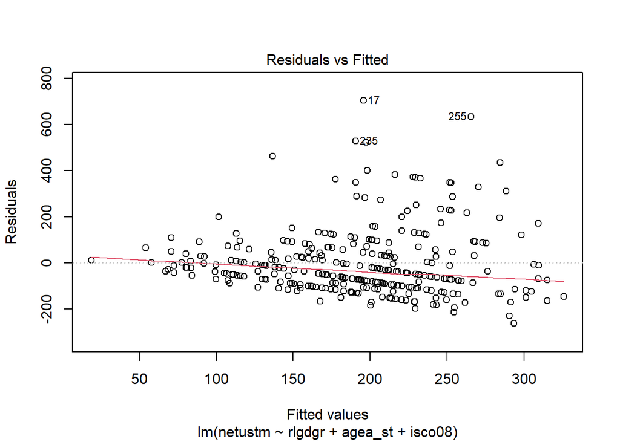

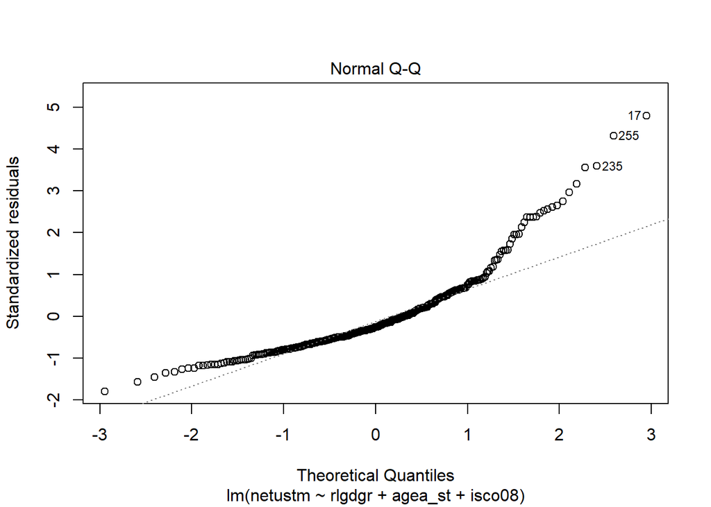

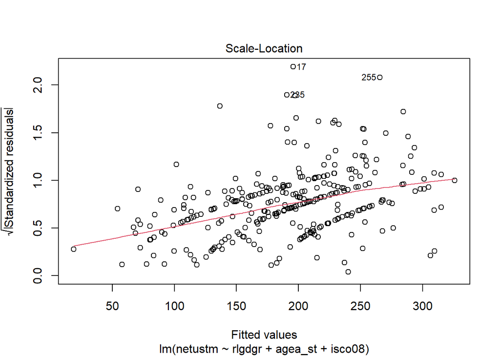

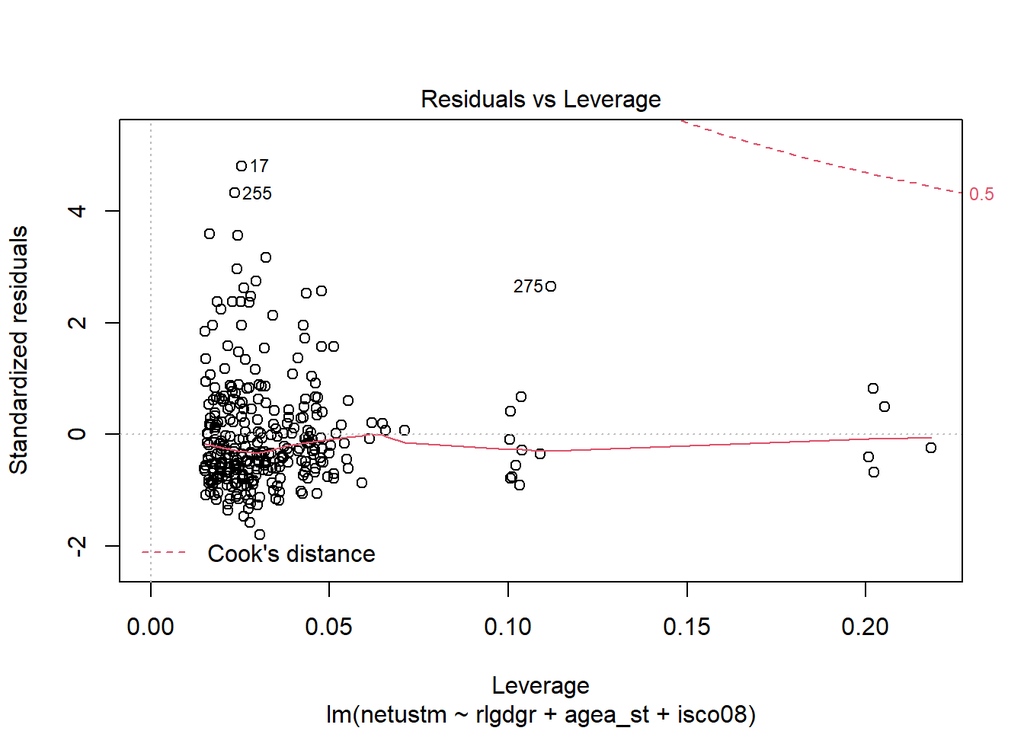

```r
plot(m3)
```

```r
cor.test(ESS_NEW2$rlgdgr, ESS_NEW2$agea, method = "spearman")
```

```
##
##  Spearman's rank correlation rho
##
## data:  ESS_NEW2$rlgdgr and ESS_NEW2$agea
## S = 4432593, p-value = 0.02813
## alternative hypothesis: true rho is not equal to 0
## sample estimates:
##       rho
## 0.1243113
```

The correlation coefficient between the predictors we chose showed not that significant p-value (0.028 which is bigger than 0.01), so the mediation effect is less probable which is also good.

## Bibliography

1. Statista.com, Share of internet users in Poland from 2015 to 2019, by age group [Electronic resource] URL: https://www.statista.com/statistics/1015451/poland-internet-users-by-age-group/
2. Wangberg, S. C., Andreassen, H. K., Prokosch, H.-U., Santana, S. M. V., Sørensen, T., & Chronaki, C. E. (2007). Relations between Internet use, socio-economic status (SES), social support and subjective health. Health Promotion International, 23(1), 70–77.
3. Armfield, G. G., & Holbert, R. L. (2003). The relationship between religiosity and Internet use. Journal of Media and Religion, 2(3), 129-144.
4. Stat.gov.pl, Infographic—Religiousness of Polish inhabitiants [Electronic resource] URL: https://stat.gov.pl/en/infographics-and-widgets/infographics/infographic-religiousness-of-polish-inhabitiants,4,1.html

# Project IV

## Introduction

We continue studying topic the topic ‘Media & Social Trust’, so the outcome variable has not changed since last project - it is still frequency of Internet usage on a typical day (netustm). This time, we will explore the interaction effect between our predictors and, again, each of us contributed to a particular part of the project:

- Mukhin Kirill: decribing the distribution of the outcome and predictors, calculating the correlation between continuous predictors , creating a regression and its interpretation, creating the model with interaction and interpreting it, creating the interaction plots and its interpretation , testing the improvement in R-squared and interpreting the results.
- Shvets Fedor: update of projects 1-3, creating a research question and hypotheses, searching for variables, testing the improvement in R-squared and interpreting the results, creating interaction plots and its interpretation, making overall conclusions.
- Kapitonov Denis: update of projects 1-3, creating a research question and hypotheses, searching for literature, searching for variables, creating the model with interaction and interpreting it, creating interaction plots and its interpretation, making overall conclusions.
- Gorokohva Anastasia: update of projects 1-3, searching for variables, creating a regression and its interpretation, creating the model with interaction and interpreting it, creating the interaction plots and its interpretation.

```r
ESS_NEW3 = ESS9 %>% select(netustm, agea, rlgatnd, isco08)

str(ESS_NEW3)
```

```
## tibble [1,500 x 4] (S3: tbl_df/tbl/data.frame)
##  $ netustm: dbl+lbl [1:1500]  60, 120, 180,  NA, 180,  NA,  90, 150,  NA,  NA,  60...
##    ..@ label        : chr "Internet use, how much time on typical day, in minutes"
##    ..@ format.spss  : chr "F4.0"
##    ..@ display_width: int 9
##    ..@ labels       : Named num [1:4] 6666 7777 8888 9999
##    .. ..- attr(*, "names")= chr [1:4] "Not applicable" "Refusal" "Don't know" "No answer"
##  $ agea   : dbl+lbl [1:1500] 37, 23, 22, 83, 36, 32, 29, 72, 45, 63, 33, 51, 27, 7...
##    ..@ label        : chr "Age of respondent, calculated"
##    ..@ format.spss  : chr "F4.0"
##    ..@ display_width: int 6
##    ..@ labels       : Named num 999
##    .. ..- attr(*, "names")= chr "Not available"
##  $ rlgatnd: dbl+lbl [1:1500] 4, 5, 6, 3, 6, 3, 4, 5, 3, 3, 3, 3, 7, 4, 3, 7, 6, 3,...
##    ..@ label        : chr "How often attend religious services apart from special occasions"
##    ..@ format.spss  : chr "F2.0"
##    ..@ display_width: int 9
##    ..@ labels       : Named num [1:10] 1 2 3 4 5 6 7 77 88 99
##    .. ..- attr(*, "names")= chr [1:10] "Every day" "More than once a week" "Once a week" "At least once a month" ...
##  $ isco08 : dbl+lbl [1:1500] 4211, 7120, 9629, 9112, 3123, 3112, 2341, 3334, 9329,...
##    ..@ label      : chr "Occupation, ISCO08"
##    ..@ format.spss: chr "F5.0"
##    ..@ labels     : Named num [1:594] 0 100 110 200 210 300 310 1000 1100 1110 ...
##    .. ..- attr(*, "names")= chr [1:594] "Armed forces occupations" "Commissioned armed forces officers" "Commissioned armed forces officers" "Non-commissioned armed forces officers" ...
```

The predictors which we took from the previous project are Age and Occupation. The new variable is Frequency of religious services attendance which is in fact have similar theme as Religiosity taken in the previous project.

- Occupation. In the work of Thompson S.H. Teo[1] there was proven the statement that depending on the type of occupation, the level of internet usage is increasing (especially for IT-workers). We expect that some categories of occupation will also effect our model in some extent - higher status occupations like Managers will have higher Internet Usage frequency and with lowering the occupational status the Internet Usage will also decline.
- Frequency of Religious Cervices Attendance. The same themed variable was already used by us in a previous project - religiosity. As we have found out, the degree of religiousness of the respondent is negatively associated with the usage of the Internet, as stated in a study by Greg G. Armfield and R. lance Holbert[2]. Now we want to look at religiosity from a different perspective. We assume that frequency of religious services attendance is also negatively related to Internet usage on a typical day. We want to know if our assumptions and results will be confirmed with the existing study.
- Age. We have the same assumption as in the previous project: older people use the internet much less than the youngers. Remembering the statistics[3], the statement is true for Poland. So this variable is expected to affect the frequency of Internet usage negatively.

We put forward a research question: Which of our chosen variables predict the frequency of Internet use on typical day in Poland in the better way and will the interaction effect between the variables improve our the predictive power of our model?

We also formulate research hypotheses:

Null hypothesis (H0):

- There is no relation between Age and outcome (Frequency of Internet usage).
- There is no relation between Frequency of religious services attendance and outcome (Frequency of Internet usage).
- There is no relation between Occupation and outcome (Frequency of Internet usage).
- There is no relation between connection of Age with Frequency of religious services attendance and outcome (Frequency of Internet usage).

Alternative hypothesis (Ha):

- There is relation between Age and outcome (Frequency of Internet usage).
- There is relation between Frequency of religious services attendance and outcome (Frequency of Internet usage).
- There is relation between Occupation and outcome (Frequency of Internet usage).
- There is relation between connection of Age with Frequency of religious services attendance and outcome (Frequency of Internet usage).

As now we have the different set of variables, let’s describe them with a table. At first, we create four vectors with original names, description, variable types, and values range.

```r
Variable_Name = c('netustm', 'isco08', 'agea', 'rlgatnd')

Description = c('Frequency of Internet usage', 'Occupation of respondent', 'Age of respondent', 'Frequency of religious services attendance (apart from special occasions as wedding or funeral)')

Variable_Type = c('Ratio', 'Nominal', 'Ratio', 'Ordinal')

Measurement <- c('0-900', 'Occupational groups coded by ISCO-08 with range from 110 to 9629', '15-87', '1-7: Every day - More than once a week - Once a week - At least once a month - Only on special hody days - Less often - Never')
```

Now let’s create a table for more convenient way of representation.

```r
data_description <- data.frame(Variable_Name, Description, Variable_Type, Measurement, stringsAsFactors = FALSE)

kable(data_description) %>%
  kable_styling(bootstrap_options = c('bordered'), full_width = FALSE)
```

| Variable_Name | Description | Variable_Type | Measurement |
| --- | --- | --- | --- |
| netustm | Frequency of Internet usage | Ratio | 0-900 |
| isco08 | Occupation of respondent | Nominal | Occupational groups coded by ISCO-08 with range from 110 to 9629 |
| agea | Age of respondent | Ratio | 15-87 |
| rlgatnd | Frequency of religious services attendance (apart from special occasions as wedding or funeral) | Ordinal | 1-7: Every day - More than once a week - Once a week - At least once a month - Only on special hody days - Less often - Never |

Let’s recode our Occupation variable: we will merge observations into larger groups of the first digit in ISCO-08 coding and name them properly. The military three-digit groups are deleted due to a few observations in it.

```r
ESS_NEW3 = ESS_NEW3 %>% filter(!isco08 %in% as.numeric(c("110", "210", "310")))
ESS_NEW3$isco08 = substring(ESS_NEW3$isco08, 1, 1)

ESS_NEW3$isco08 = as.factor(ESS_NEW3$isco08)
levels(ESS_NEW3$isco08)[1] <- "Managers"
levels(ESS_NEW3$isco08)[2] <- "Professionals"
levels(ESS_NEW3$isco08)[3] <- "Technicians and associate professionals"
levels(ESS_NEW3$isco08)[4] <- "Clerical support workers"
levels(ESS_NEW3$isco08)[5] <- "Service and sales workers"
levels(ESS_NEW3$isco08)[6] <- "Skilled agricultural, forestry and fishery workers"
levels(ESS_NEW3$isco08)[7] <- "Craft and related trades workers"
levels(ESS_NEW3$isco08)[8] <- "Plant and machine operators, and assemblers"
levels(ESS_NEW3$isco08)[9] <- "Elementary occupations"
```

Now let’s check if there are coded missing values as “Refusal”, “Don’t know” - they are represented by the big numbers like 6666, 7777 or 8888.

```r
table(ESS_NEW3$netustm)
```

```
##
##   0  10  15  20  30  40  45  50  60  65  80  90  95 100 105 120 135 140 145 150
##   3   1   3   3  42   3   7   2 143   1   2  52   1   2   1 160   2   1   1  25
## 155 165 170 180 200 210 215 220 225 240 255 270 285 300 330 360 390 420 450 480
##   1   1   1 130   2  18   1   1   1  69   1  10   1  53   1  30   3  11   1  24
## 540 600 720 900
##   7  17   7   4
```

```r
table(ESS_NEW3$rlgatnd)
```

```
##
##   1   2   3   4   5   6   7
##   8  65 601 295 301  94  91
```

```r
table(ESS_NEW3$agea)
```

```
##
## 15 16 17 18 19 20 21 22 23 24 25 26 27 28 29 30 31 32 33 34 35 36 37 38 39 40
## 12 21 23 23 21 22 16 22 22 22 22 23 24 24 18 18 31 20 24 35 25 25 28 30 27 28
## 41 42 43 44 45 46 47 48 49 50 51 52 53 54 55 56 57 58 59 60 61 62 63 64 65 66
## 25 30 21 23 20 16 22 21 21 14 18 27 14 21 21 24 18 21 21 31 27 35 31 27 24 33
## 67 68 69 70 71 72 73 74 75 76 77 78 79 80 81 82 83 84 85 86 87
## 23 25 21 25 19 18 16  9 11  9 13 11  8 17 11 12  9 12  5  6  1
```

```r
table(ESS_NEW3$isco08)
```

```
##
##                                           Managers
##                                                168
##                                      Professionals
##                                                184
##            Technicians and associate professionals
##                                                178
##                           Clerical support workers
##                                                 74
##                          Service and sales workers
##                                                192
## Skilled agricultural, forestry and fishery workers
##                                                123
##                   Craft and related trades workers
##                                                160
##        Plant and machine operators, and assemblers
##                                                131
##                             Elementary occupations
##                                                 95
```

Hopefully, there are none of such observations. Now let’s remove all NA’s so making sure that all our observations contain information about the variables.

```r
ESS_NEW3 = na.omit(ESS_NEW3)
```

## Data Exploration

Let’s look at the summary statistics of a chosen variables.

```r
summary(ESS_NEW3)
```

```
##     netustm           agea          rlgatnd
##  Min.   :  0.0   Min.   :15.00   Min.   :1.000
##  1st Qu.: 60.0   1st Qu.:30.00   1st Qu.:3.000
##  Median :120.0   Median :39.00   Median :4.000
##  Mean   :175.6   Mean   :40.86   Mean   :4.237
##  3rd Qu.:240.0   3rd Qu.:51.00   3rd Qu.:5.000
##  Max.   :900.0   Max.   :84.00   Max.   :7.000
##
##                                          isco08
##  Professionals                              :150
##  Service and sales workers                  :120
##  Managers                                   :116
##  Technicians and associate professionals    :105
##  Craft and related trades workers           : 68
##  Plant and machine operators, and assemblers: 52
##  (Other)                                    : 94
```

As we can see, the outcome variable has the asymmetrical distribution - it has the 3rd quartile of 240 (which is also distant from the median), but the maximum of 900, so at least one huge outlier exists. Median is less than mean value, so the right skeweness is proposed. As age’s mean and median are very close to each other, the distribution seem to be close to normal, also the 1st and the 3rd quartiles looks symmetrical. Although at least one positive outlier exists (84). The quartiles of frequency of religious services attendance are symmetrical - 3 and 5 with the median of 4. Mean (4.237) and median are roughly close, and minimum and maximum are symmetrical - 1 and 7. As for occupation, we see that Professionals group is the biggest one with 150 observations, however, other groups could have at least three times less observations in it as Plant and machine operators (52).

Let’s check the variables’ outliers with boxplots.

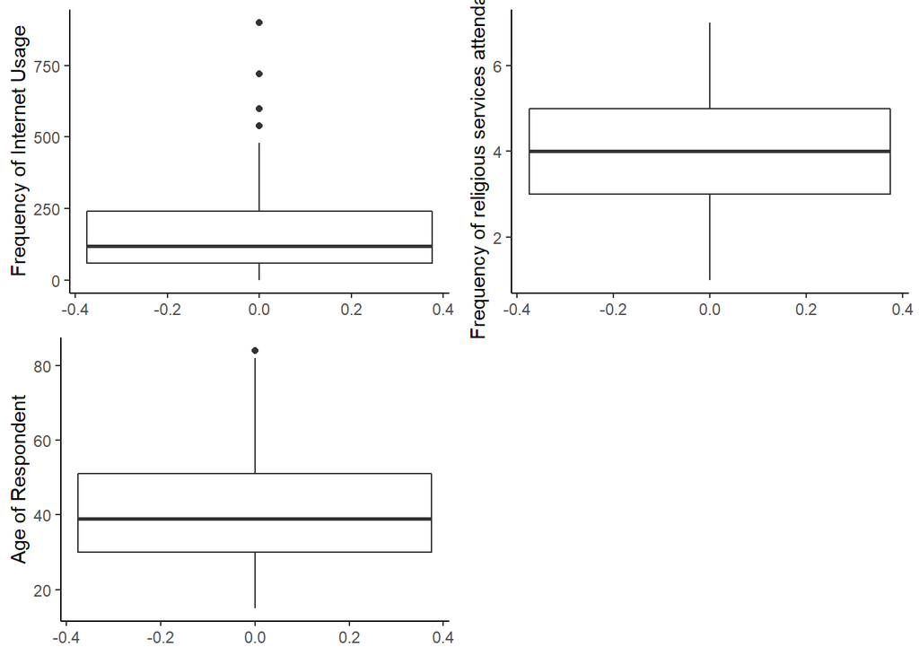

```r
a = ggplot(ESS_NEW3, aes(y = netustm)) +
  geom_boxplot() +
  ylab("Frequency of Internet Usage") +
  theme_classic()

b = ggplot(ESS_NEW3, aes(y = rlgatnd)) +
  geom_boxplot() +
  ylab("Frequency of religious services attendance") +
  theme_classic()

c = ggplot(ESS_NEW3, aes(y = agea)) +
  geom_boxplot() +
  ylab("Age of Respondent") +
  theme_classic()

grid.arrange(a, b, c, ncol = 2)
```

The outcome variable has four outliers, although the age has only one and frequency of religious services attendance has no outliers at all.

Now let’s check the distributions with histograms.

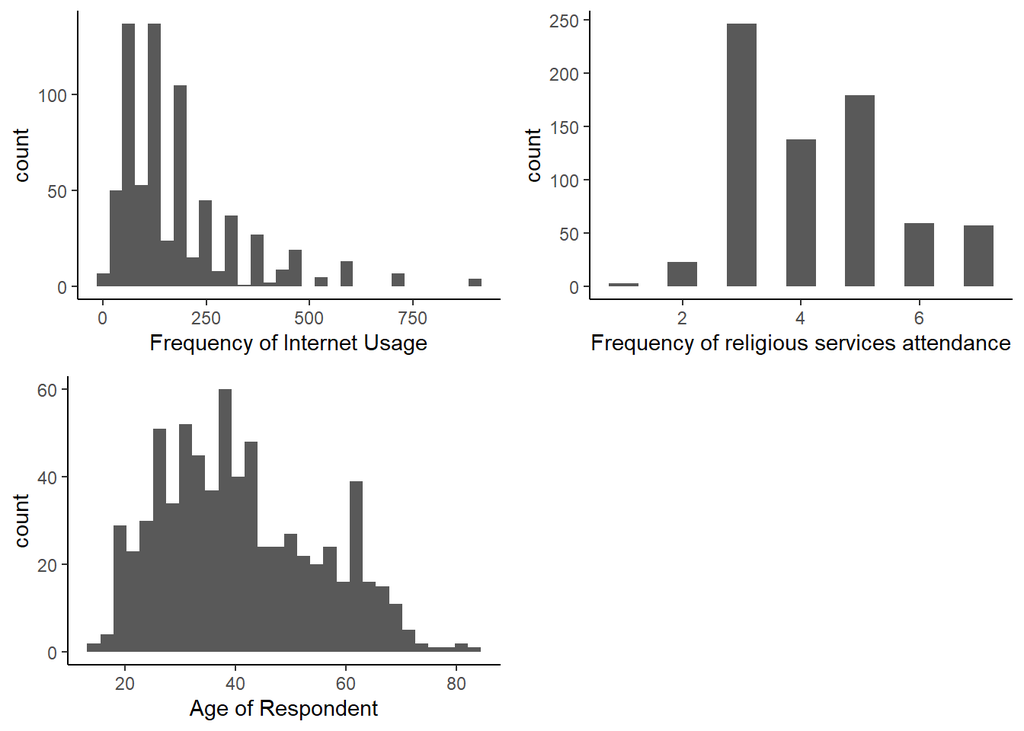

```r
e = ggplot(data = ESS_NEW3, aes(x = netustm)) +
  geom_histogram() +
  xlab("Frequency of Internet Usage") +
  theme_classic()

f = ggplot(data = ESS_NEW3, aes(x = rlgatnd)) +
  geom_histogram(binwidth = 0.5) +
  xlab("Frequency of religious services attendance") +
  theme_classic()

g = ggplot(data = ESS_NEW3, aes(x = agea)) +
  geom_histogram() +
  xlab("Age of Respondent") +
  theme_classic()

grid.arrange(e, f, g, ncol = 2)
```

As it was expected, the outcome variable has right-skeweness, other variables also represent non normal distribution.

Now we switch to the categorical occupation variable - let’s visualize it’s groups with barplot.

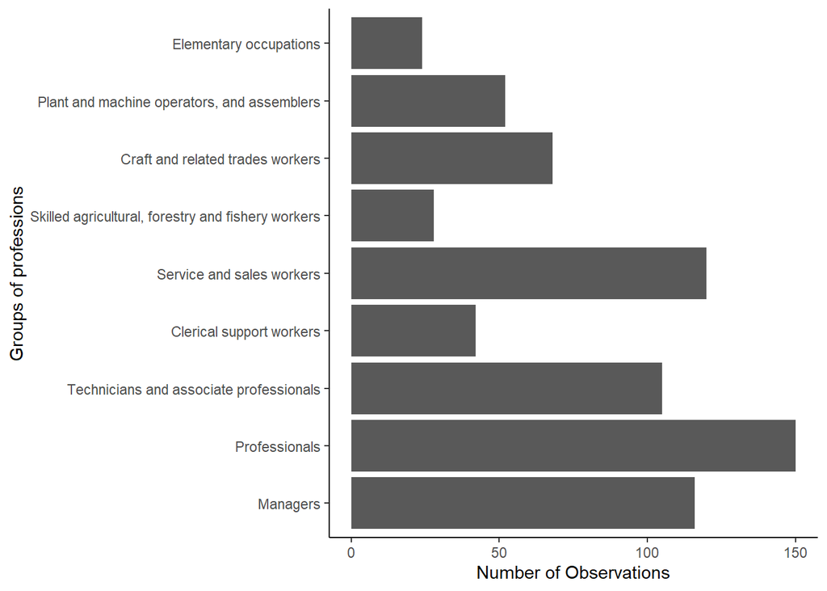

```r
ggplot(ESS_NEW3, aes(x = isco08)) +
  geom_bar() +
  xlab("Groups of professions") +
  ylab("Number of Observations") +
  coord_flip() +
  theme_classic()
```

Professionals and Service and sales workers have the highest number observations. However, some groups like Elementary occupations and Skilles agricultural, foresty and fishery workers have much less.

Now we will check if the continuos variables are really correlated to the outcome with scatteplots.

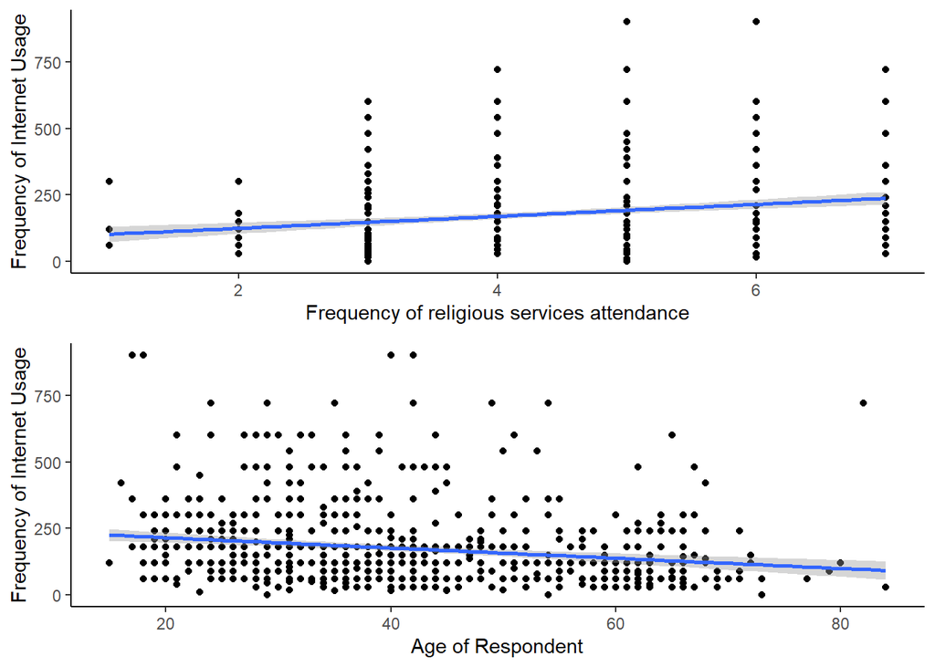

```r
i = ggplot(data = ESS_NEW3, aes(x = rlgatnd, y = netustm)) +
  geom_point() +
  geom_smooth(method = "lm") +
  xlab("Frequency of religious services attendance") +
  ylab("Frequency of Internet Usage") +
  theme_classic()

j = ggplot(data = ESS_NEW3, aes(x = agea, y = netustm)) +
  geom_point() +
  geom_smooth(method = "lm") +
  xlab("Age of Respondent") +
  ylab("Frequency of Internet Usage") +
  theme_classic()

grid.arrange(i, j, nrow = 2)
```

The Frequence of religious services attendance and Frequency of Internet Usage are positively correlated. The Age is negatively correlated with the outcome. The slope does not seem to be big.

## Correlation matrix

Let’s now look at the correlation matrix and see what are the exact correlation coefficient. We use spearman-method as our data has non normal distribution.

```r
tab_corr(ESS_NEW3[,1:3], corr.method = "spearman")
```

|  | Internet use, how much time on typical day, in minutes | Age of respondent, calculated | How often attend religious services apart from special occasions |
| --- | --- | --- | --- |
| Internet use, how much time on typical day, in minutes |  | -0.250*** | 0.208*** |
| Age of respondent, calculated | -0.250*** |  | -0.059 |
| How often attend religious services apart from special occasions | 0.208*** | -0.059 |  |
| Computed correlation used spearman-method with listwise-deletion. |  |  |  |

As it was seen in scatterplots, Age is negatively correlated to the outcome variable and Frequency of Religious Services Attendance - positively. We see that the matrix indicates the low correlation with coefficients -0.25 and 0.208 respectively. Although, it is satisfying. Moreover, we can notice that predictors are not correlated with each other at all - the coefficient equals to -0.059 which is a good indicator.

Now let’s check the significance of the correlation between the outcome and its predictors.

```r
cor.test(ESS_NEW3$netustm, ESS_NEW3$agea, method = "spearman")
```

```
##
##  Spearman's rank correlation rho
##
## data:  ESS_NEW3$netustm and ESS_NEW3$agea
## S = 72992909, p-value = 1.699e-11
## alternative hypothesis: true rho is not equal to 0
## sample estimates:
##        rho
## -0.2498717
```

```r
cor.test(ESS_NEW3$netustm, ESS_NEW3$rlgatnd, method = "spearman")
```

```
##
##  Spearman's rank correlation rho
##
## data:  ESS_NEW3$netustm and ESS_NEW3$rlgatnd
## S = 46225453, p-value = 2.31e-08
## alternative hypothesis: true rho is not equal to 0
## sample estimates:
##       rho
## 0.2084726
```

Both p-values are less than 0.01 and show the statistical significance of the correlations between both predictors and the outcome.

## Linear Regression Models

Now we construct regression models. At the first step, as in a previous project, we construct the regression model with only one predictor, which is categorical in order to find out how the frequency of Internet usage can be predicted by a respondent’s occupation. The next step, is making the second model by adding another predictor - the age, which is continuous in order to make our model better for predicting the frequency of Internet usage on typical day. But, as usual, it is needed to change the “agea” variable to make it start from 0, so that intercept value will be interpretable. The last step, we add the third predictor, which is ordinal, to find out if the Frequency of religious services attendance will help us better predict the chosen outcome. We will immediately compare all the models to determine the best one, and then add an interactive effect. But, let’s firstly recode agea variable. The same should be done with rlgatnd variable so it starts with zero, so we could interpret intercept value. We reassign labels after changing the variable.

```r
table(ESS_NEW3$agea)
```

```
##
## 15 16 17 18 19 20 21 22 23 24 25 26 27 28 29 30 31 32 33 34 35 36 37 38 39 40
##  2  1  3  6  9 14 11 12 15 15 16 16 19 21 13 13 24 15 18 27 18 19 21 20 19 20
## 41 42 43 44 45 46 47 48 49 50 51 52 53 54 55 56 57 58 59 60 61 62 63 64 65 66
## 20 20 11 17 12 12  9 15  9  6 12 15  7  8 12  8  9  7 10  6 11 13 15  5 11 11
## 67 68 69 70 71 72 73 77 79 80 82 84
##  4  5  4  2  3  2  2  1  1  1  1  1
```

```r
ESS_NEW3$agea_st = ESS_NEW3$agea - 15
table(ESS_NEW3$agea_st)
```

```
##
##  0  1  2  3  4  5  6  7  8  9 10 11 12 13 14 15 16 17 18 19 20 21 22 23 24 25
##  2  1  3  6  9 14 11 12 15 15 16 16 19 21 13 13 24 15 18 27 18 19 21 20 19 20
## 26 27 28 29 30 31 32 33 34 35 36 37 38 39 40 41 42 43 44 45 46 47 48 49 50 51
## 20 20 11 17 12 12  9 15  9  6 12 15  7  8 12  8  9  7 10  6 11 13 15  5 11 11
## 52 53 54 55 56 57 58 62 64 65 67 69
##  4  5  4  2  3  2  2  1  1  1  1  1
```

```r
table(ESS_NEW3$rlgatnd)
```

```
##
##   1   2   3   4   5   6   7
##   3  23 246 138 179  59  57
```

```r
ESS_NEW3$rlgatnd1 = ESS_NEW3$rlgatnd - 1
table(ESS_NEW3$rlgatnd1)
```

```
##
##   0   1   2   3   4   5   6
##   3  23 246 138 179  59  57
```

```r
ESS_NEW3$rlgatnd1 <- sjlabelled::set_labels(ESS_NEW3$rlgatnd1, labels = c("Every day", "More than once a week", "Once a week", "At least once a month", "Only on special holy days", "Less often", "Never"))

ESS_NEW3$netustm = as.numeric(ESS_NEW3$netustm)
ESS_NEW3$agea_st = as.numeric(ESS_NEW3$agea_st)
```

Now we create regression models.

```r
m1 <- lm(netustm ~ isco08, data = ESS_NEW3)
m2 <- lm(netustm ~ isco08 + agea_st, data = ESS_NEW3)
m3 <- lm(netustm ~ isco08 + agea_st + rlgatnd1, data = ESS_NEW3)

anova(m1, m2, m3)
```

```
## Analysis of Variance Table
##
## Model 1: netustm ~ isco08
## Model 2: netustm ~ isco08 + agea_st
## Model 3: netustm ~ isco08 + agea_st + rlgatnd1
##   Res.Df      RSS Df Sum of Sq      F    Pr(>F)
## 1    696 14722104
## 2    695 13936004  1    786100 40.526 3.527e-10 ***
## 3    694 13461757  1    474247 24.449 9.579e-07 ***
## ---
## Signif. codes:  0 '***' 0.001 '**' 0.01 '*' 0.05 '.' 0.1 ' ' 1
```

As we can see, each sequent model is better than the previous as all p-values are less than 0.01 and thus show statistical significance. The third model with three predictors is the best then, so we can use it to add the interaction effect. Moreover, we can notice that the F value decreases as we add new predictors which is a good sign.

## Interaction Effect

Now let’s add the intercation effect to the third model. We chose the agea and rlgatnd variable for it - in this case Frequency of Religious Services Attendance will be a moderator for the relationship between Age and Frequency of Internet Usage. Also, we compare all four models in order to check if the interaction effect help us to predict the outcome better.

```r
m4 <- lm(netustm ~ isco08 + agea_st * rlgatnd1, data = ESS_NEW3)

anova(m1, m2, m3, m4)
```

```
## Analysis of Variance Table
##
## Model 1: netustm ~ isco08
## Model 2: netustm ~ isco08 + agea_st
## Model 3: netustm ~ isco08 + agea_st + rlgatnd1
## Model 4: netustm ~ isco08 + agea_st * rlgatnd1
##   Res.Df      RSS Df Sum of Sq       F    Pr(>F)
## 1    696 14722104
## 2    695 13936004  1    786100 40.9219 2.915e-10 ***
## 3    694 13461757  1    474247 24.6878 8.501e-07 ***
## 4    693 13312364  1    149392  7.7769  0.005437 **
## ---
## Signif. codes:  0 '***' 0.001 '**' 0.01 '*' 0.05 '.' 0.1 ' ' 1
```

As we see, the p-value for the fourth model is also less than 0.01 and thus statistically significant, so the fourth model predicts better than the third. Therefore, we can see how the predictive power increases with the additions of new predictors and the interaction effect.

```r
tab_model(m1, m2, m3, m4)
```

|  | netustm |  |  | netustm |  |  | netustm |  |  | netustm |  |  |
| --- | --- | --- | --- | --- | --- | --- | --- | --- | --- | --- | --- | --- |
| Predictors | Estimates | CI | p | Estimates | CI | p | Estimates | CI | p | Estimates | CI | p |
| (Intercept) | 207.54 | 181.03 – 234.06 | **<0.001** | 284.93 | 249.50 – 320.36 | **<0.001** | 212.97 | 167.91 – 258.04 | **<0.001** | 150.55 | 87.76 – 213.34 | **<0.001** |
| isco 08: Professionals | -10.41 | -45.72 – 24.90 | 0.563 | -20.43 | -54.95 – 14.09 | 0.246 | -12.53 | -46.62 – 21.57 | 0.471 | -14.52 | -48.48 – 19.44 | 0.401 |
| isco 08: Technicians and associate professionals | -21.16 | -59.63 – 17.30 | 0.280 | -32.33 | -69.95 – 5.28 | 0.092 | -29.84 | -66.85 – 7.17 | 0.114 | -33.21 | -70.11 – 3.70 | 0.078 |
| isco 08: Clerical support workers | -30.76 | -82.18 – 20.67 | 0.241 | -47.42 | -97.76 – 2.92 | 0.065 | -43.24 | -92.78 – 6.30 | 0.087 | -43.07 | -92.37 – 6.23 | 0.087 |
| isco 08: Service and sales workers | -39.21 | -76.39 – -2.03 | **0.039** | -66.58 | -103.78 – -29.37 | **<0.001** | -59.90 | -96.59 – -23.22 | **0.001** | -61.99 | -98.53 – -25.45 | **0.001** |
| isco 08: Skilled agricultural,forestry and fishery workers | -94.86 | -154.99 – -34.74 | **0.002** | -106.39 | -165.04 – -47.74 | **<0.001** | -85.23 | -143.53 – -26.94 | **0.004** | -88.67 | -146.74 – -30.61 | **0.003** |
| isco 08: Craft and related trades workers | -57.40 | -101.01 – -13.78 | **0.010** | -78.29 | -121.25 – -35.32 | **<0.001** | -69.13 | -111.55 – -26.72 | **0.001** | -74.70 | -117.09 – -32.31 | **0.001** |
| isco 08: Plant and machine operators,and assemblers | -85.81 | -133.47 – -38.16 | **<0.001** | -104.50 | -151.27 – -57.73 | **<0.001** | -96.71 | -142.81 – -50.61 | **<0.001** | -98.21 | -144.11 – -52.32 | **<0.001** |
| isco 08: Elementary occupations | -71.29 | -135.33 – -7.26 | **0.029** | -103.11 | -166.25 – -39.97 | **0.001** | -95.14 | -157.32 – -32.95 | **0.003** | -98.80 | -160.74 – -36.87 | **0.002** |
| agea st |  |  |  | -2.44 | -3.20 – -1.67 | **<0.001** | -2.36 | -3.11 – -1.60 | **<0.001** | -0.05 | -1.84 – 1.74 | 0.957 |
| rlgatnd 1 |  |  |  |  |  |  | 19.73 | 11.90 – 27.56 | **<0.001** | 39.26 | 23.45 – 55.06 | **<0.001** |
| agea_st:rlgatnd1 |  |  |  |  |  |  |  |  |  | -0.70 | -1.19 – -0.21 | **0.005** |
| Observations | 705 |  |  | 705 |  |  | 705 |  |  | 705 |  |  |
| R<sup>2</sup> / R<sup>2</sup> adjusted | 0.036 / 0.025 |  |  | 0.087 / 0.076 |  |  | 0.119 / 0.106 |  |  | 0.128 / 0.114 |  |  |

If we look at the fourth model, we can firstly see that the intercept value is significant and has the value of 150.55 meaning that with the occupational group of Managers and zero level of other two predictors (agea_st = 0 which is 15 and rlgatnd1 = 0 which is 1 - Every day) the predicted level of Internet Usage will be 150.55 minutes a day. Then we see that some levels of occupation are not statistically significant as they have p-value bigger than 0.01. However, five levels, as previously, are significant. For example, Service and sales workers have significant p-value of 0.001 and the estimate of -61.99 - it means that if we hold age and frequency of religiosity services attendance constant and switch from Managers groups to Service and sales workers, then the Frequency of Internet Usage will decrease by -61.99. The age alone is no longer statistically significant, however, the rlgatnd1 does. If we look at the interaction effect between these two variables, we notice the statistical significance of this effect with p-value 0.005 and estimate -0.7. It means that we hold constant the Managers group and simultaneously increase age and rlgatnd1 by 1, so that the age increases by 1 year and the frequency of religiosity services attendance thus decreases as the bigger values meaning the less attendance frequency in our case (so that we switch form Every day to More than once a week) and our outcome variable decreases by 0.7. The predictive power increased in the fourth model - now we have R-squared = 0.128 and adjusted R-squared = 0.114, so that 11,4% of the outcome variation can be explained by our model.

Now we can conclude that as we added new predictors and interaction effect to it, the predictive power of our model increased from 2,5% to 11,4% which is a satisfactory level of predictive power for us.

```r
summary(m4)
```

```
##
## Call:
## lm(formula = netustm ~ isco08 + agea_st * rlgatnd1, data = ESS_NEW3)
##
## Residuals:
##     Min      1Q  Median      3Q     Max
## -245.68  -85.04  -34.76   39.94  678.14
##
## Coefficients:
##                                                           Estimate Std. Error
## (Intercept)                                              150.54847   31.98071
## isco08Professionals                                      -14.52027   17.29638
## isco08Technicians and associate professionals            -33.20934   18.79665
## isco08Clerical support workers                           -43.07334   25.10916
## isco08Service and sales workers                          -61.99330   18.61045
## isco08Skilled agricultural, forestry and fishery workers -88.67359   29.57300
## isco08Craft and related trades workers                   -74.69766   21.59034
## isco08Plant and machine operators, and assemblers        -98.21487   23.37310
## isco08Elementary occupations                             -98.80272   31.54428
## agea_st                                                   -0.04968    0.91045
## rlgatnd1                                                  39.25784    8.04996
## agea_st:rlgatnd1                                          -0.69954    0.25085
##                                                          t value Pr(>|t|)
## (Intercept)                                                4.707 3.03e-06 ***
## isco08Professionals                                       -0.839 0.401480
## isco08Technicians and associate professionals             -1.767 0.077707 .
## isco08Clerical support workers                            -1.715 0.086711 .
## isco08Service and sales workers                           -3.331 0.000911 ***
## isco08Skilled agricultural, forestry and fishery workers  -2.998 0.002811 **
## isco08Craft and related trades workers                    -3.460 0.000574 ***
## isco08Plant and machine operators, and assemblers         -4.202 2.99e-05 ***
## isco08Elementary occupations                              -3.132 0.001808 **
## agea_st                                                   -0.055 0.956503
## rlgatnd1                                                   4.877 1.34e-06 ***
## agea_st:rlgatnd1                                          -2.789 0.005437 **
## ---
## Signif. codes:  0 '***' 0.001 '**' 0.01 '*' 0.05 '.' 0.1 ' ' 1
##
## Residual standard error: 138.6 on 693 degrees of freedom
## Multiple R-squared:  0.1283, Adjusted R-squared:  0.1145
## F-statistic: 9.272 on 11 and 693 DF,  p-value: 1.23e-15
```

Among, above mentioned coefficients, we have several more in summary statistics for our model. We see that the residuals of the outcome variable are asymmetrically distributed - the positive values have at least one huge outlier of 678.14 with the 3rd Quartile of only 39.94, so that the model does not predict the outcome in a good way. The standard errors are big for all occupational groups starting from 17.29 up to 31.54, so that big variation is possible. However, the interaction effect standard error is smallest one - 0.25 - which is a good indicator. The absolute t values are relatively big for most of the predictors except age alone (-0.055) and Professional group (-0.839), so that all corresponding regression coefficients are different from 0 but for these predictors it is not that trustable. Residual standard error is big - thus our model does not fit very well. The overall p-value for the model is less than 0.01 and thus statistically significant, so that our model predicts better than a random one.

So, we can propose a new equation for our model:

- netustm = 150.55 - 14.52 * Professionals - 33.21 * Technicians and associate professionals - 43.07 * Clerical support workers - 61.99 * Service and sales workers - 88.67 * Skilled agricultural, forestry and fishery workers - 74.70 * Craft and related trades workers - 98.21 * Plant and machine operators, and assemblers - 98.80 * Elementary occupations - 0.05 * Age of respondent + 39.25 * How often attend religious services apart from special occasions - 0.70 * agea_st * rlgatnd

## Interaction Plot

Now that we explored the model statistics, let’s construct the interaction plot.

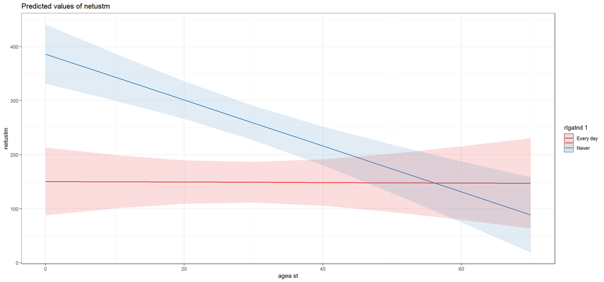

```r
plot_model(m4, type = "int") +
  theme_bw()
```

The two polar attendance levels were taken authomaticly - Every day and Never. From the interaction plot we can see that till the rescaled age of approximately 38 (in the real age it is 53) the difference between these two levels remains. After this age, the confidence intervals intersects, so that the difference dissappear. Thus, we see that at all age levels the Every day attendance does not affect the Internet Usage. On the opposite, with becoming older, with none attendance at all the frequencty of Internet usage decreases and starting with 38 (53) years old, the difference between these two attendance levels vanishes.

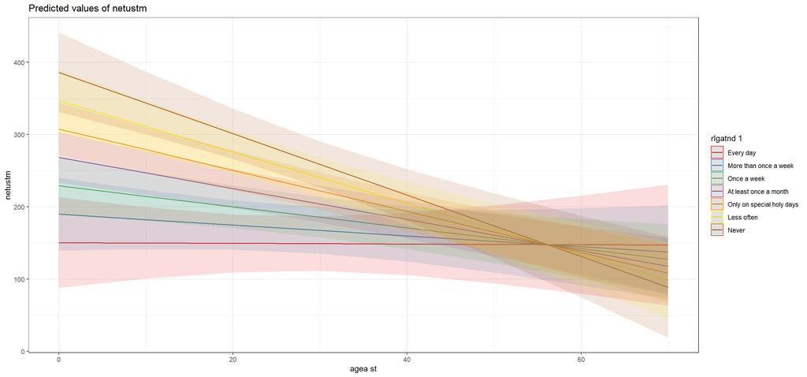

```r
plot_model(m4, type = "int", mdrt.values = "all") + theme_bw()
```

## Linear Regression Assimptions Check

As we’ve already mentioned, while our model presents satisfactory predictive power, its fit is not the best. Notice, that it also does not meet the assumptions as the residuals are distributed assymetrically and non normaly with high positive ones, so it decreases the fit quality. However, as well as in the previous project, no values crossed the Cook’s distance, so it is good indicator.

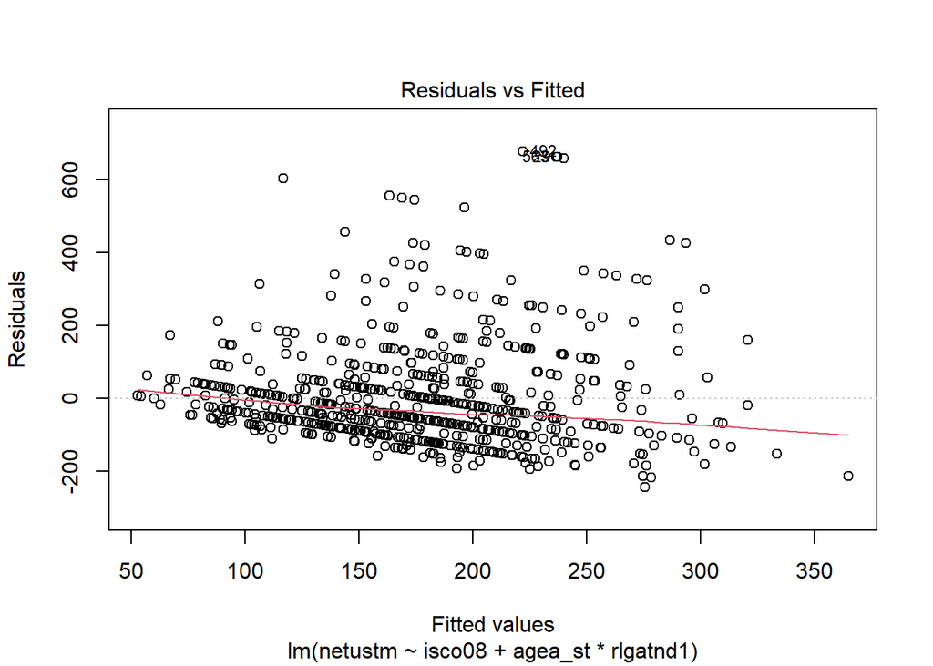

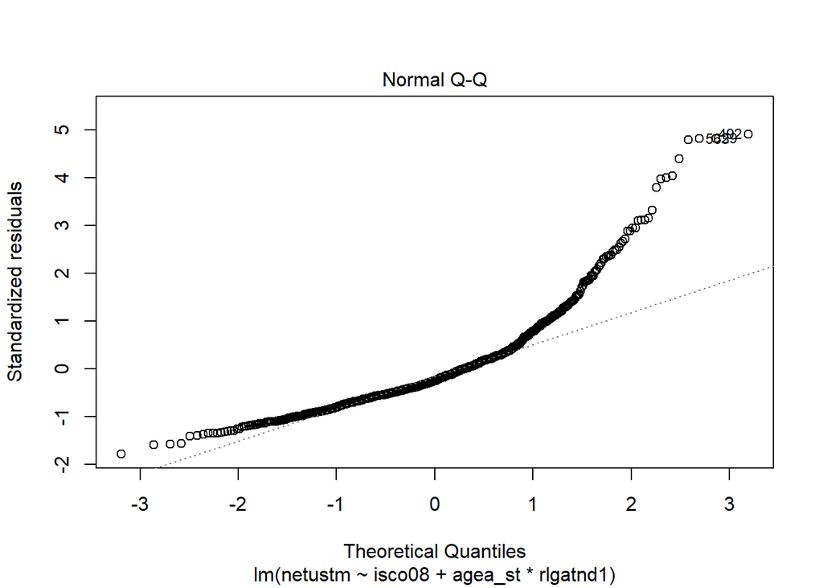

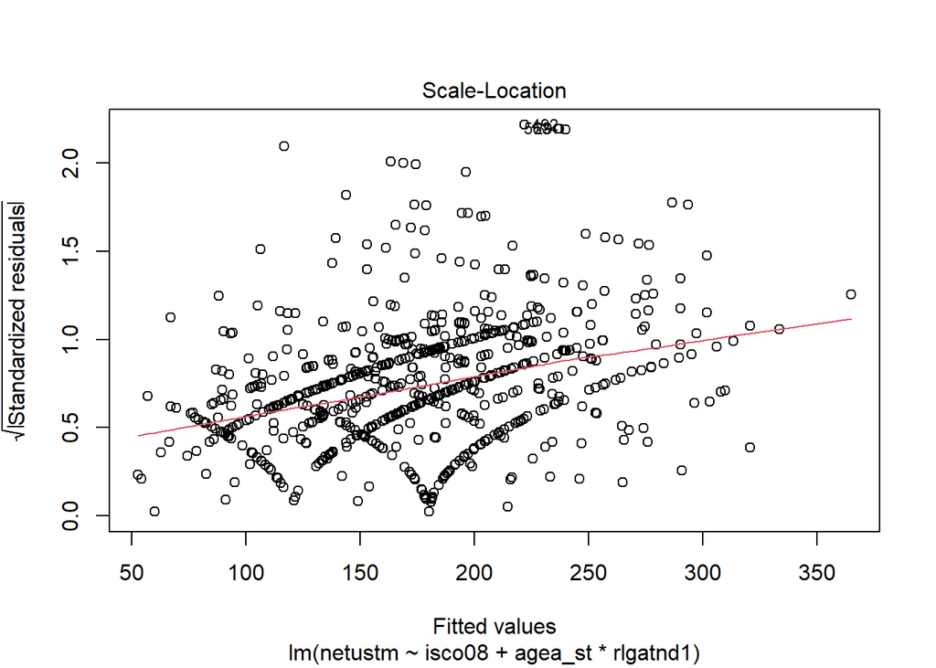

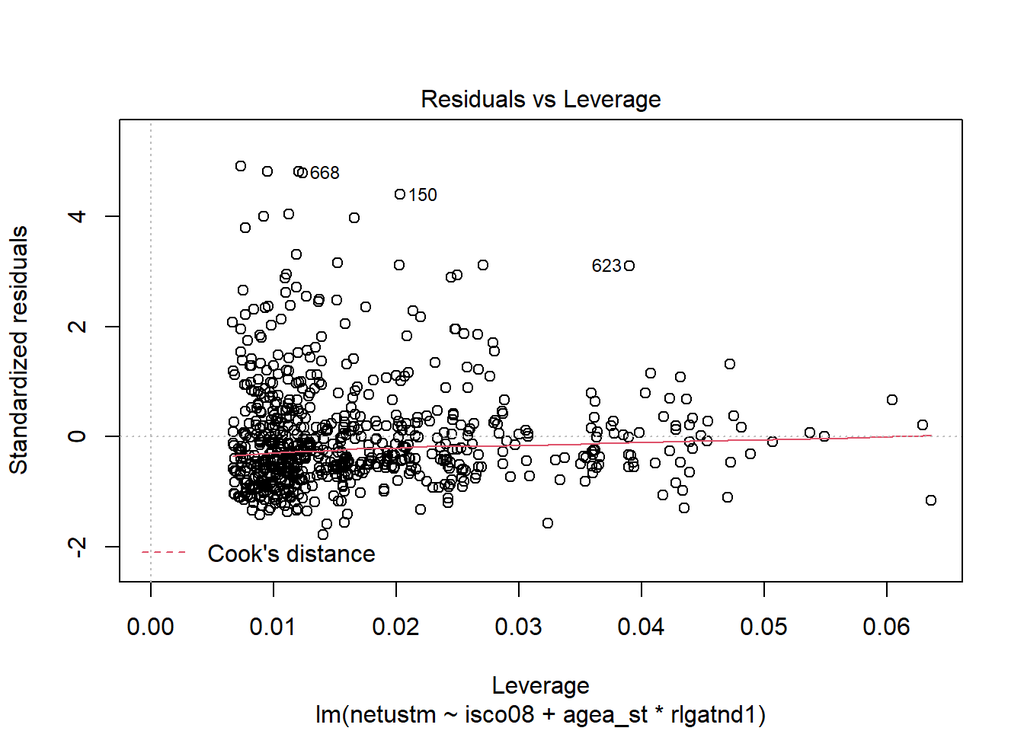

```r
plot(m4)
```

Also, we can state that there is no correlation between the variables in interaction effect, so it is also good for the model.

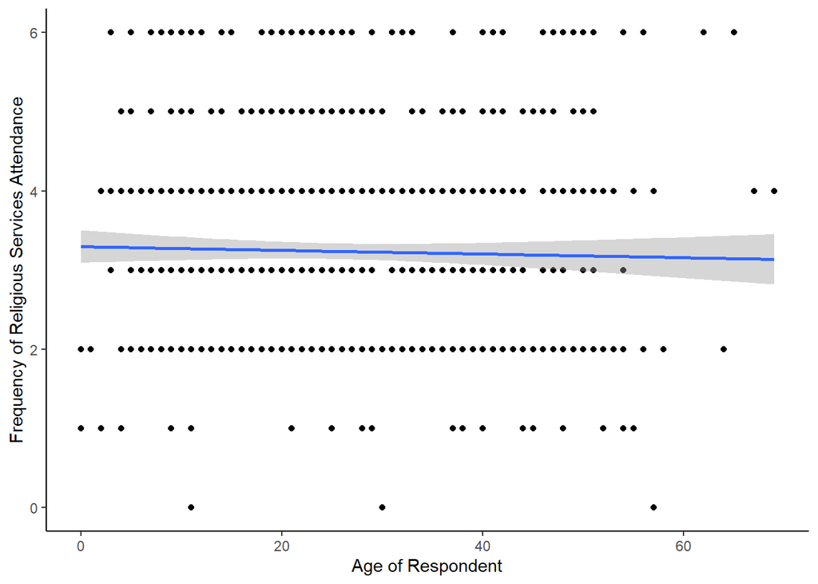

```r
ggplot(data = ESS_NEW3, aes(x = agea_st, y = rlgatnd1)) +
  geom_point() +
  geom_smooth(method = "lm") +
  xlab("Age of Respondent") +
  ylab("Frequency of Religious Services Attendance") +
  theme_classic()
```

## Bibliography

1. Teo, T.S.H. (1998), “Differential effects of occupation on Internet usage”, Internet Research, Vol. 8 No. 2, pp. 156-165.
2. Armfield, G. G., & Holbert, R. L. (2003). The relationship between religiosity and Internet use. Journal of Media and Religion, 2(3), 129-14.
3. Statista.com, Share of internet users in Poland from 2015 to 2019, by age group [Electronic resource] URL: https://www.statista.com/statistics/1015451/poland-internet-users-by-age-group/